# Network analysis using DNA metabarcoding data discloses important roles and links in the seabird community of the Eastern Tropical Atlantic

```r
require(readxl)
require(tidyverse)
require(dplyr)
require(plyr)
require(reshape2)
require(ape)
require(BiodiversityR)
require(ggplot2)
require(ggrepel)
require(ggpubr)
require(vegan)
require(iNEXT)
require(EcoSimR)
require(divo)
require(mvabund)
require(gplots)
require(MASS)
require(caret)
require(leaps)
require(effects)
require(spaa)
require(lattice)
require(patchwork)
require(RVAideMemoire)
require(bipartite)
require(car)
```

# 1 Data preparation

> For this work we will analyse the diet composition of the seabird community of Cabo Verde.

> Three seabird species breed throughout the year, i.e., continuous breeders:
> - Brown booby (*Sula leucogaster*; SL),
> - Red-billed tropicbird (*Phaethon aethereus*; PA)
> - Cape Verde storm-petrel (*Hydrobates jabejabe*; HJ).

> And three seabird species are seasonal breeders, two breeding in summer, and one in winter:
> - Cape Verde shearwater (*Calonectris edwardsii*; CE) - Summer
> - Bulwer’s petrel (*Bulweria bulwerii*; BB) - Summer
> - Boyd’s shearwaters (*Puffinus lherminieri boydi*; PB) - Winter

## 1.1 Matrices

The database was imported

```r
data_seabirds <- read_excel("Database.xlsx", sheet = 1, na = "")

data_seabirds <- as.data.frame(data_seabirds)
```

Data was formatted as a matrix of samples x MOTU

```r
sample.matrix.motu.wide <- dcast(data_seabirds, Extraction_ID ~ final_id, function(x) if(length(x)>=1) 1 else 0, value.var = "final_id")

PA.matrix.motu <- sample.matrix.motu.wide %>% remove_rownames %>% column_to_rownames(var="Extraction_ID")
```

The factors of each sample was extracted

```r
factors <-data_seabirds %>% dplyr::select(Extraction_ID, host_species, Year, Guild, Site, season, host_season)

factors <- distinct(factors, Extraction_ID, .keep_all = TRUE)
factors[] <- lapply(factors[colnames(factors)], as.factor)

factors.ord <- factors[order(factors$Extraction_ID),] # to order samples
factors.ord <- factors.ord %>% remove_rownames %>% column_to_rownames(var="Extraction_ID")

factors.ord[] <- lapply(factors.ord[colnames(factors.ord)], as.factor)
```

> Data was analysed at two scales of resolution:
> - Community scale - To explore interspecific and inter-seasonal differences
> - Seasonal scale - To assess the contribution of each seasonal populations to the trophic network

# 2 Data analysis - Community scale

## 2.1 Frequency of occurence (%)

```r
sample.matrix.motu.long <- gather(sample.matrix.motu.wide, Species, Presence, "Acanthuridae":"Trichiuridae", factor_key=TRUE)
sample.matrix.motu.long <- merge(sample.matrix.motu.long, factors)

sample.matrix.motu.long.good <- ddply(.data = sample.matrix.motu.long, .var = c("host_species", "Species"), .fun = summarise,
    n = length(Presence),
    present = sum(Presence %in% c("1")),
    prop = present / n * 100
)

sample.matrix.motu.wide.good <- sample.matrix.motu.long.good %>%
  subset(select=c("host_species", "n", "Species", "prop"))%>%
  spread(Species, prop)
sample.matrix.motu.wide.good <- sample.matrix.motu.wide.good %>% remove_rownames %>% column_to_rownames(var="host_species")

sample.matrix.motu.wide.good
```

|  | n | Acanthuridae | Acanthurus sp. | Apletodon sp. | Apogon imberbis | Argyropelecus sladeni | Arothron sp. | Assimineidae | Asthenognathus atlanticus | Atherina sp. | Brotula sp. | Carangidae | Cavolinia uncinata | Cephalopholis sp. | Ceratoscopelus sp. | Chelon auratus | Chromis chromis | Conger conger | Coryphaena equiselis | Cyclothone pallida | Decapterus macarellus | Decapterus punctactus | Derichthys serpentinus | Diacria sp.1 | Diacria sp.2 | Diaphus dumerilli | Diplodus sargus | Diplodus vulgaris | Engraulis encrasicolus | … |
| --- | --- | --- | --- | --- | --- | --- | --- | --- | --- | --- | --- | --- | --- | --- | --- | --- | --- | --- | --- | --- | --- | --- | --- | --- | --- | --- | --- | --- | --- | --- |
| BB | 25 | 0.000000 | 4 | 4 | 0.000000 | 4 | 0.000000 | 4 | 0.000000 | 12 | 4 | 0.000000 | 0.000000 | 0.000000 | 4 | 8 | 8.00000 | 0.000000 | 0.000000 | 0.000000 | 0.000000 | 0.000000 | 0.000000 | 0.000000 | 0.000000 | 0.000000 | 4 | 4 | 4.000000 | … |
| CE | 30 | 0.000000 | 0 | 0 | 0.000000 | 0 | 3.333333 | 0 | 0.000000 | 0 | 0 | 0.000000 | 0.000000 | 6.666667 | 0 | 0 | 13.33333 | 3.333333 | 10.000000 | 3.333333 | 3.333333 | 0.000000 | 3.333333 | 0.000000 | 0.000000 | 0.000000 | 0 | 0 | 13.333333 | … |
| HJ | 12 | 0.000000 | 0 | 0 | 8.333333 | 25 | 0.000000 | 0 | 0.000000 | 0 | 0 | 0.000000 | 0.000000 | 0.000000 | 0 | 0 | 0.00000 | 0.000000 | 0.000000 | 0.000000 | 0.000000 | 0.000000 | 0.000000 | 0.000000 | 0.000000 | 8.333333 | 0 | 0 | 0.000000 | … |
| PA | 41 | 0.000000 | 0 | 0 | 0.000000 | 0 | 2.439024 | 0 | 0.000000 | 0 | 0 | 0.000000 | 2.439024 | 0.000000 | 0 | 0 | 19.51220 | 0.000000 | 0.000000 | 0.000000 | 2.439024 | 0.000000 | 0.000000 | 2.439024 | 2.439024 | 0.000000 | 0 | 0 | 0.000000 | … |
| PB | 21 | 4.761905 | 0 | 0 | 0.000000 | 0 | 9.523810 | 0 | 4.761905 | 0 | 0 | 4.761905 | 0.000000 | 9.523810 | 0 | 0 | 9.52381 | 0.000000 | 0.000000 | 0.000000 | 4.761905 | 0.000000 | 0.000000 | 0.000000 | 0.000000 | 0.000000 | 0 | 0 | 4.761905 | … |
| SL | 49 | 0.000000 | 0 | 0 | 0.000000 | 0 | 2.040816 | 0 | 0.000000 | 0 | 0 | 0.000000 | 0.000000 | 4.081633 | 0 | 0 | 20.40816 | 0.000000 | 2.040816 | 0.000000 | 2.040816 | 2.040816 | 0.000000 | 0.000000 | 0.000000 | 0.000000 | 0 | 0 | 0.000000 | … |

### 2.1.1 Ranked Frequency of occurence (FO) plots

To build the Ranked Frequency of occurrence plots, the FO table was separated by all seabird species, to allow to rank each seabird’ prey by its %FO. Then, the individual matrices were merged together to build the plot.

Plot

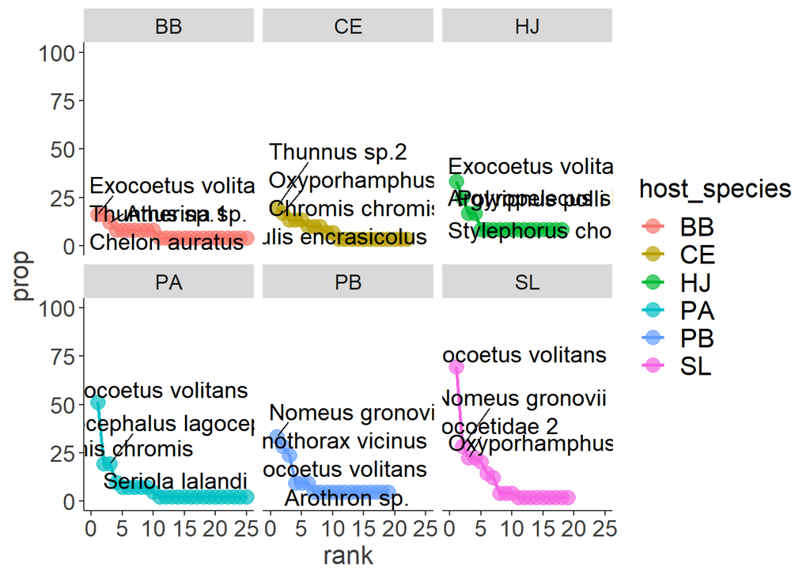

```r
BioR.theme <- theme(
        panel.background = element_blank(),
        panel.border = element_blank(),
        panel.grid = element_blank(),
        axis.line = element_line("gray25"),
        text = element_text(size = 16, family="Helvetica"),
        axis.text = element_text(size = 14, colour = "gray25"),
        axis.title = element_text(size = 16, colour = "gray25"),
        legend.title = element_text(size = 16),
        legend.text = element_text(size = 16),
        legend.key = element_blank())


FOplot.spp <- ggplot(data=FO_plot_spp, aes(x = rank, y = prop)) +
    xlim(0, 25) +
    ylim(0, 100) +
    geom_line(aes(colour=host_species), size=1) +
    geom_point(aes(colour=host_species), size=4, alpha=0.7) +
    geom_text_repel(data=subset(FO_plot_spp, rank < 5),
        aes(label=Species),
        angle=0, size = 5, nudge_x=5, nudge_y=5, show.legend=FALSE) +
    BioR.theme + facet_wrap(~ host_species)
FOplot.spp
```

## 2.2 Comparissons of MOTU Richness

### 2.2.1 Accumulation curves

Matrices per species

```r
PA.matrix.motu.phaeton <- dcast(subset(data_seabirds, host_species=="PA"), Extraction_ID ~ final_id, function(x) if(length(x)>=1) 1 else 0, value.var = "final_id")
PA.matrix.motu.phaeton <- PA.matrix.motu.phaeton %>% remove_rownames %>% column_to_rownames(var="Extraction_ID")

PA.matrix.motu.sula_leuco <- dcast(subset(data_seabirds, host_species=="SL"), Extraction_ID ~ final_id, function(x) if(length(x)>=1) 1 else 0, value.var = "final_id")
PA.matrix.motu.sula_leuco <- PA.matrix.motu.sula_leuco %>% remove_rownames %>% column_to_rownames(var="Extraction_ID")

PA.matrix.motu.calonectris <- dcast(subset(data_seabirds, host_species=="CE"), Extraction_ID ~ final_id, function(x) if(length(x)>=1) 1 else 0, value.var = "final_id")
PA.matrix.motu.calonectris <- PA.matrix.motu.calonectris %>% remove_rownames %>% column_to_rownames(var="Extraction_ID")

PA.matrix.motu.bulweria <- dcast(subset(data_seabirds, host_species=="BB"), Extraction_ID ~ final_id, function(x) if(length(x)>=1) 1 else 0, value.var = "final_id")
PA.matrix.motu.bulweria <- PA.matrix.motu.bulweria %>% remove_rownames %>% column_to_rownames(var="Extraction_ID")

PA.matrix.motu.puffinus <- dcast(subset(data_seabirds, host_species=="PB"), Extraction_ID ~ final_id, function(x) if(length(x)>=1) 1 else 0, value.var = "final_id")
PA.matrix.motu.puffinus <- PA.matrix.motu.puffinus %>% remove_rownames %>% column_to_rownames(var="Extraction_ID")

PA.matrix.motu.hydrobates <- dcast(subset(data_seabirds, host_species=="HJ"), Extraction_ID ~ final_id, function(x) if(length(x)>=1) 1 else 0, value.var = "final_id")
PA.matrix.motu.hydrobates <- PA.matrix.motu.hydrobates %>% remove_rownames %>% column_to_rownames(var="Extraction_ID")
```

Plots

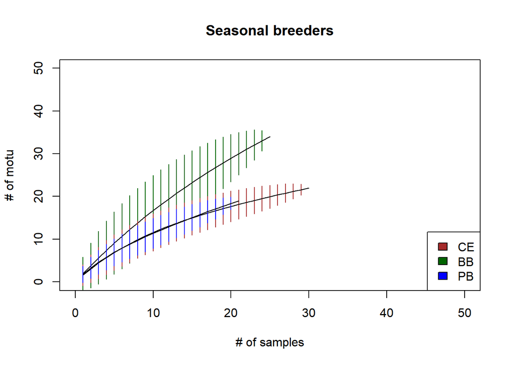

```r
specaccum(PA.matrix.motu.calonectris) -> accum.calonectris
specaccum(PA.matrix.motu.bulweria) -> accum.bulweria
specaccum(PA.matrix.motu.puffinus) -> accum.puffinus


plot(accum.bulweria, main= "Seasonal breeders", xlim = c(0,50), ylim = c(0,50), xlab = "# of samples", ylab = "# of motu", ci.col="darkgreen")
plot(accum.calonectris, ci.col="brown", add=T)
plot(accum.puffinus, ci.col="blue", add=T)
legend(x="bottomright", legend=c("CE", "BB", "PB"), fill=c( "brown", "darkgreen","blue"))
```

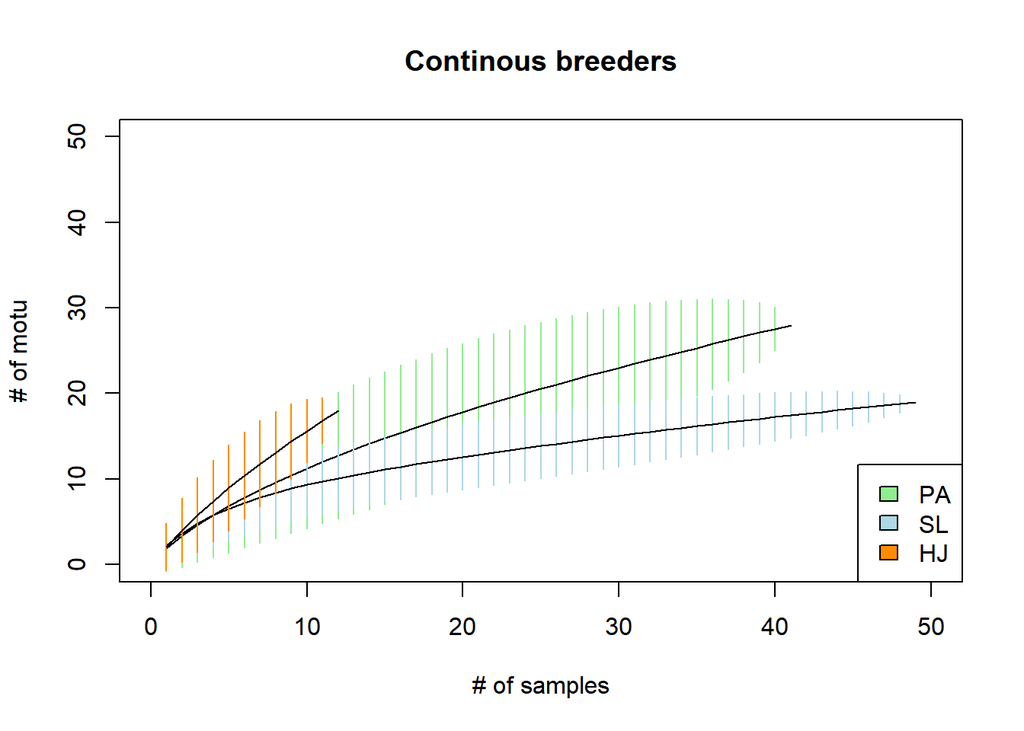

```r
specaccum(PA.matrix.motu.phaeton) -> accum.phaeton
specaccum(PA.matrix.motu.sula_leuco) -> accum.sula_leuco
specaccum(PA.matrix.motu.hydrobates) -> accum.hydrobates

plot(accum.phaeton, main= "Continous breeders", xlim = c(0,50), ylim = c(0,50), xlab = "# of samples", ylab = "# of motu", ci.col="lightgreen")
plot(accum.sula_leuco, ci.col="lightblue", add=T)
plot(accum.hydrobates, ci.col="darkorange", add=T)
legend(x="bottomright", legend=c("PA", "SL", "HJ"), fill=c("lightgreen","lightblue", "darkorange") )
```

### 2.2.2 Extrapolation of MOTU Diversity

Incidence matrices were built, and two lists were defined: one with seasonal breeders, other with continuous breeders, to call their curves separately.

```r
incidence.matrix.motu.phaeton <- as.data.frame(t(PA.matrix.motu.phaeton))
incidence.matrix.motu.sula_leuco <- as.data.frame(t(PA.matrix.motu.sula_leuco))
incidence.matrix.motu.bulweria <- as.data.frame(t(PA.matrix.motu.bulweria))
incidence.matrix.motu.calonectris <- as.data.frame(t(PA.matrix.motu.calonectris))
incidence.matrix.motu.puffinus <- as.data.frame(t(PA.matrix.motu.puffinus))
incidence.matrix.motu.hydrobates <- as.data.frame(t(PA.matrix.motu.hydrobates))


list_seabirds1 = list(BB = incidence.matrix.motu.bulweria, CE = incidence.matrix.motu.calonectris, PB = incidence.matrix.motu.puffinus)

list_seabirds2 = list(PA = incidence.matrix.motu.phaeton, SL = incidence.matrix.motu.sula_leuco, HJ = incidence.matrix.motu.hydrobates)

ChaoEst <- ChaoRichness(c(list_seabirds1,list_seabirds2), datatype="incidence_raw", conf = 0.95)
ChaoEst
```

|  | Observed | Estimator | Est_s.e. | 95% Lower | 95% Upper |
| --- | --- | --- | --- | --- | --- |
| BB | 34 | 73.497 | 22.855 | 47.776 | 147.243 |
| CE | 22 | 56.800 | 32.311 | 29.420 | 185.203 |
| PB | 19 | 45.825 | 22.093 | 25.547 | 128.912 |
| PA | 28 | 186.049 | 175.181 | 55.341 | 941.632 |
| SL | 19 | 32.224 | 12.217 | 21.836 | 80.660 |
| HJ | 18 | 62.917 | 40.375 | 27.939 | 220.979 |

Plots

- **Seasonal breeders**

```r
seabirds_diversity_CE.BB.PB <- iNEXT(list_seabirds1, datatype="incidence_raw")
seabirds_diversity_CE.BB.PB
```

```
## Compare 3 assemblages with Hill number order q = 0.
## $class: iNEXT
##
## $DataInfo: basic data information
##   site  T  U S.obs     SC Q1 Q2 Q3 Q4 Q5 Q6 Q7 Q8 Q9 Q10
## 1   BB 25 49    34 0.5218 24  7  1  2  0  0  0  0  0   0
## 2   CE 30 48    22 0.7528 12  2  3  3  1  1  0  0  0   0
## 3   PB 21 37    19 0.6566 13  3  0  0  1  1  1  0  0   0
##
## $iNextEst: diversity estimates with rarefied and extrapolated samples.
## $BB
##     t       method order     qD qD.LCL qD.UCL    SC SC.LCL SC.UCL
## 1   1 interpolated     0  1.960  1.357  2.563 0.037  0.004  0.071
## 10 12 interpolated     0 19.463 14.517 24.408 0.335  0.219  0.451
## 20 25     observed     0 34.000 25.997 42.003 0.522  0.401  0.642
## 30 37 extrapolated     0 43.889 33.905 53.873 0.642  0.499  0.784
## 40 50 extrapolated     0 51.829 39.722 63.935 0.738  0.591  0.884
##
## $CE
##     t       method order     qD qD.LCL qD.UCL    SC SC.LCL SC.UCL
## 1   1 interpolated     0  1.600  1.124  2.076 0.078  0.039  0.116
## 10 15 interpolated     0 15.002 11.524 18.480 0.636  0.510  0.762
## 20 30     observed     0 22.000 16.327 27.673 0.753  0.636  0.870
## 30 44 extrapolated     0 27.145 19.411 34.880 0.789  0.669  0.910
## 40 60 extrapolated     0 32.101 21.814 42.389 0.825  0.704  0.945
##
## $PB
##     t       method order     qD qD.LCL qD.UCL    SC SC.LCL SC.UCL
## 1   1 interpolated     0  1.762  1.195  2.329 0.132  0.041  0.224
## 10 10 interpolated     0 11.371  8.219 14.523 0.558  0.422  0.694
## 20 21     observed     0 19.000 13.758 24.242 0.657  0.499  0.814
## 30 31 extrapolated     0 24.472 17.237 31.708 0.727  0.547  0.907
## 40 42 extrapolated     0 29.211 19.365 39.058 0.787  0.603  0.972
##
##
## $AsyEst: asymptotic diversity estimates along with related statistics.
##   Site         Diversity Observed Estimator   s.e.    LCL     UCL
## 1   BB  Species richness   34.000    73.497 22.855 47.776 147.243
## 2   BB Shannon diversity   29.970    65.199 13.152 39.422  90.976
## 3   BB Simpson diversity   25.817    51.356 11.648 28.526  74.186
## 4   CE  Species richness   22.000    56.800 32.311 29.420 185.203
## 5   CE Shannon diversity   17.624    29.729  7.243 17.624  43.924
## 6   CE Simpson diversity   14.769    20.226  4.443 14.769  28.934
## 7   PB  Species richness   19.000    45.825 22.093 25.547 128.912
## 8   PB Shannon diversity   13.768    25.024  6.970 13.768  38.684
## 9   PB Simpson diversity   10.141    12.992  3.192 10.141  19.249
##
## NOTE: Only show five estimates, call iNEXT.object$iNextEst. to show complete output.
```

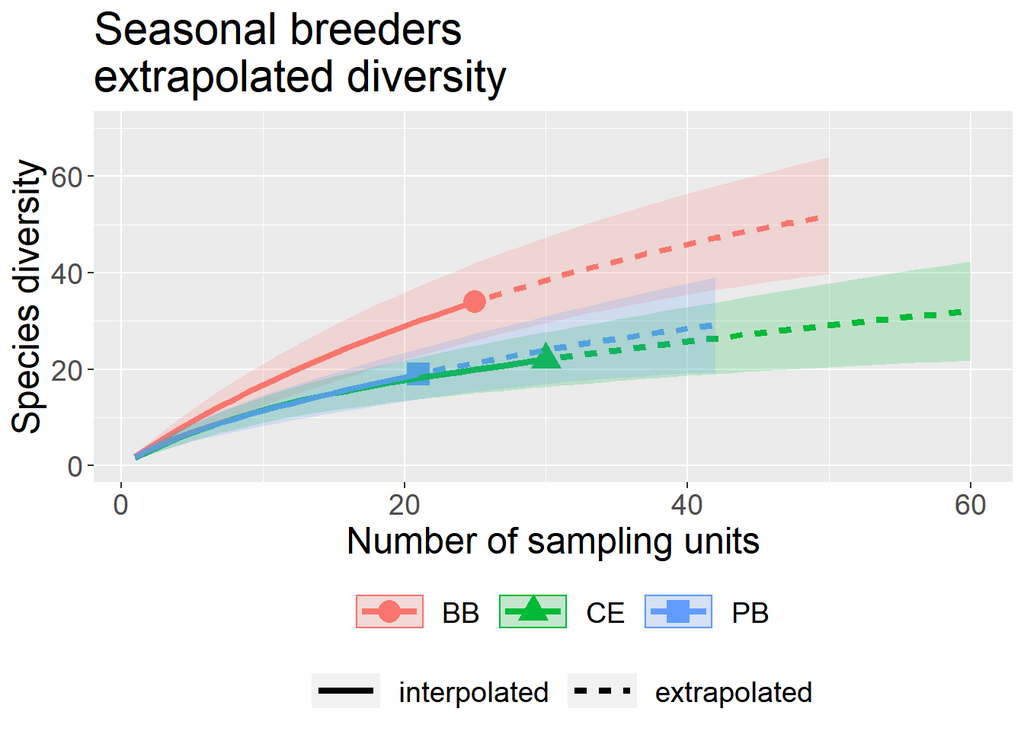

```r
ggiNEXT(seabirds_diversity_CE.BB.PB) + ylim (c(0,70)) + ggtitle("Seasonal breeders \nextrapolated diversity")
```

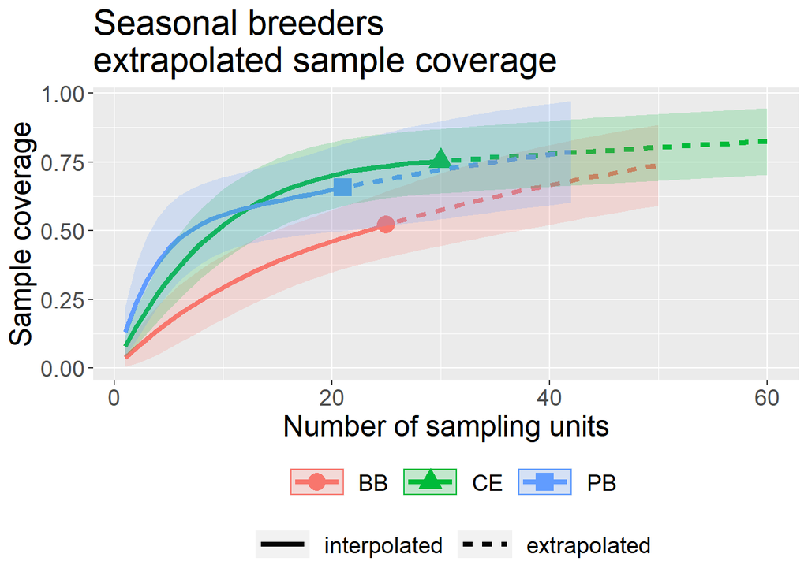

```r
ggiNEXT(seabirds_diversity_CE.BB.PB, type = 2)  + ggtitle("Seasonal breeders \nextrapolated sample coverage")
```

- **Continuous breeders**

```r
seabirds_diversity_PA.SL.HJ <- iNEXT(list_seabirds2, datatype="incidence_raw")
seabirds_diversity_PA.SL.HJ
```

```
## Compare 3 assemblages with Hill number order q = 0.
## $class: iNEXT
##
## $DataInfo: basic data information
##   site  T   U S.obs     SC Q1 Q2 Q3 Q4 Q5 Q6 Q7 Q8 Q9 Q10
## 1   PA 41  76    28 0.7638 18  1  5  1  0  0  0  2  0   0
## 2   SL 49 108    19 0.9178  9  3  0  0  0  1  1  0  0   1
## 3   HJ 12  25    18 0.4542 14  2  1  1  0  0  0  0  0   0
##
## $iNextEst: diversity estimates with rarefied and extrapolated samples.
## $PA
##     t       method order     qD qD.LCL qD.UCL    SC SC.LCL SC.UCL
## 1   1 interpolated     0  1.854  1.412  2.296 0.189  0.100  0.279
## 10 20 interpolated     0 17.837 12.717 22.958 0.695  0.605  0.785
## 20 41     observed     0 28.000 18.577 37.423 0.764  0.667  0.860
## 30 60 extrapolated     0 36.114 22.745 49.483 0.776  0.671  0.881
## 40 82 extrapolated     0 44.991 26.917 63.064 0.789  0.675  0.904
##
## $SL
##     t       method order     qD qD.LCL qD.UCL    SC SC.LCL SC.UCL
## 1   1 interpolated     0  2.204  1.960  2.449 0.326  0.264  0.389
## 10 24 interpolated     0 13.624 11.296 15.952 0.887  0.845  0.928
## 20 49     observed     0 19.000 15.124 22.876 0.918  0.881  0.954
## 30 72 extrapolated     0 22.595 17.411 27.780 0.940  0.900  0.980
## 40 98 extrapolated     0 25.497 18.607 32.387 0.958  0.917  1.000
##
## $HJ
##     t       method order     qD qD.LCL qD.UCL    SC SC.LCL SC.UCL
## 1   1 interpolated     0  2.083  1.279  2.888 0.080  0.000  0.174
## 2   1 interpolated     0  2.083  1.279  2.888 0.080  0.000  0.174
## 10  6 interpolated     0 10.424  6.943 13.906 0.336  0.137  0.534
## 11  6 interpolated     0 10.424  6.943 13.906 0.336  0.137  0.534
## 20 12     observed     0 18.000 11.824 24.176 0.454  0.195  0.713
## 30 18 extrapolated     0 24.405 15.399 33.412 0.532  0.236  0.828
## 31 18 extrapolated     0 24.405 15.399 33.412 0.532  0.236  0.828
## 40 24 extrapolated     0 29.897 17.842 41.952 0.599  0.288  0.910
##
##
## $AsyEst: asymptotic diversity estimates along with related statistics.
##   Site         Diversity Observed Estimator    s.e.    LCL     UCL
## 1   PA  Species richness   28.000   186.049 175.181 55.341 941.632
## 2   PA Shannon diversity   15.544    29.712   8.481 15.544  46.335
## 3   PA Simpson diversity    8.859     9.679   1.941  8.859  13.484
## 4   SL  Species richness   19.000    32.224  12.217 21.836  80.660
## 5   SL Shannon diversity    9.622    11.178   1.301  9.622  13.728
## 6   SL Simpson diversity    6.480     6.711   0.666  6.480   8.017
## 7   HJ  Species richness   18.000    62.917  40.375 27.939 220.979
## 8   HJ Shannon diversity   15.711    44.800  21.561 15.711  87.059
## 9   HJ Simpson diversity   13.298    25.083  14.854 13.298  54.197
##
## NOTE: Only show five estimates, call iNEXT.object$iNextEst. to show complete output.
```

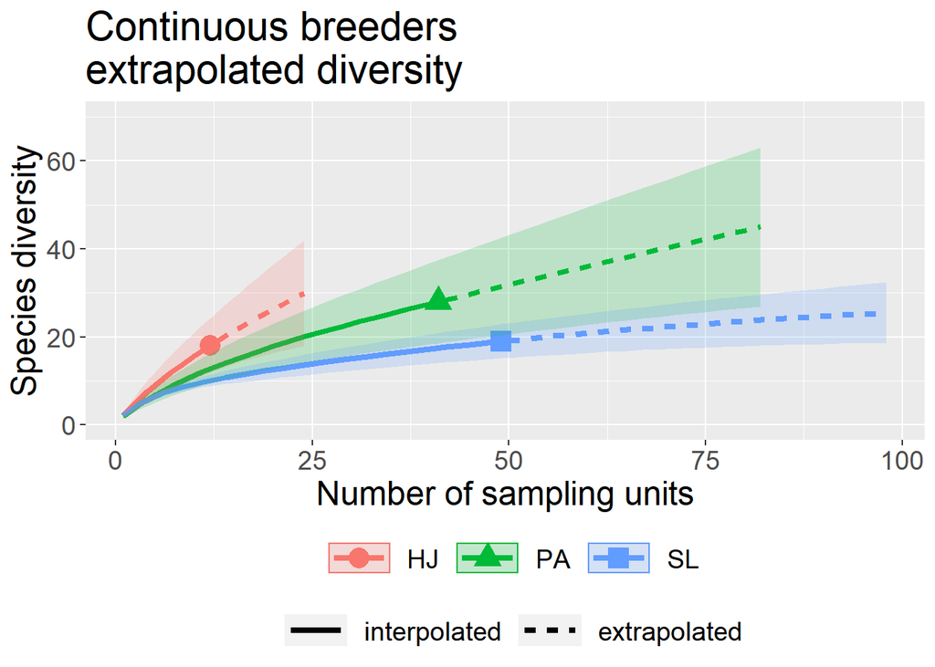

```r
ggiNEXT(seabirds_diversity_PA.SL.HJ) + ylim (c(0,70)) + ggtitle("Continuous breeders \nextrapolated diversity")
```

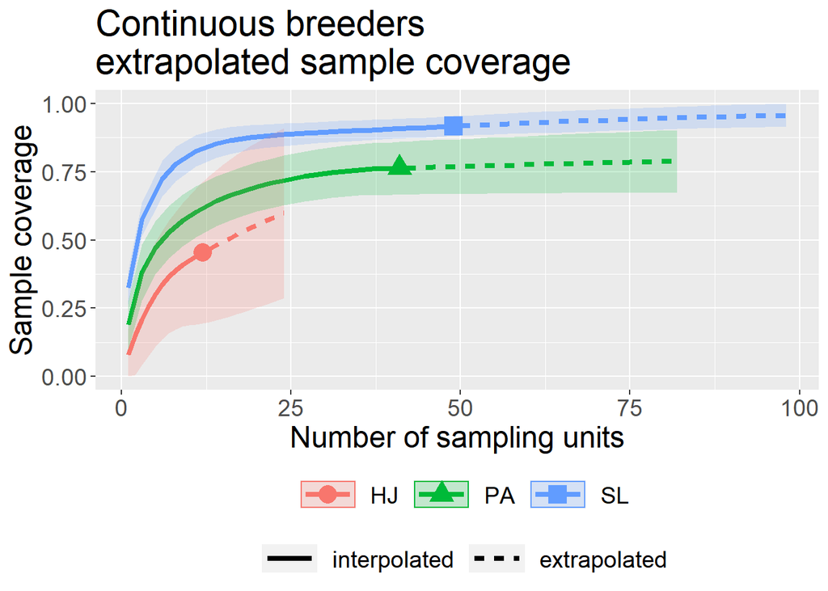

```r
ggiNEXT(seabirds_diversity_PA.SL.HJ, type = 2) + ggtitle("Continuous breeders \nextrapolated sample coverage")
```

## 2.3 Network analysis using FO%

An interaction network from the whole MOTU matrix was built using the FO% to index the strength of interactions. Then, we used several metrics to quantify several key characteristics of the network.

```r
seabirds.net.matrix <- sample.matrix.motu.long.good[,c(1,2,5)] %>% filter(prop > 0) %>% dplyr::rename(higher = host_species, lower = Species, freq = prop)
seabirds.net.matrix$webID = "caboverde"
seabirds.net.matrix <- seabirds.net.matrix[, c(1, 2, 4, 3)]

seq.high <- as.data.frame(seabirds.net.matrix$higher)%>% dplyr::rename(seq.high = "seabirds.net.matrix$higher") %>% distinct(seq.high)
seq.low <- as.data.frame(seabirds.net.matrix$lower)%>% dplyr::rename(seq.low = "seabirds.net.matrix$lower") %>% distinct(seq.low)

seabirds.network <- frame2webs(data.frame(seabirds.net.matrix),type.out="list")
```

### 2.3.1 Species level metrics

```r
species_indeces <- specieslevel(seabirds.network$caboverde, index=c("normalised degree", "d"))
species_indeces
```

```
## $`higher level`
##    normalised.degree         d
## BB         0.3908046 0.5623811
## CE         0.2528736 0.4805723
## HJ         0.2068966 0.7328455
## PA         0.3218391 0.3921165
## PB         0.2183908 0.5116702
## SL         0.2183908 0.4032775
##
## $`lower level`
##                               normalised.degree          d
## Acanthuridae                          0.1666667 0.29672239
## Acanthurus sp.                        0.1666667 0.26690688
## Apletodon sp.                         0.1666667 0.26690688
## Apogon imberbis                       0.1666667 0.34169711
## Argyropelecus sladeni                 0.3333333 0.35656878
## Arothron sp.                          0.6666667 0.16218157
## Assimineidae                          0.1666667 0.26690688
## Asthenognathus atlanticus             0.1666667 0.29672239
## Atherina sp.                          0.1666667 0.38662316
## Brotula sp.                           0.1666667 0.26690688
## Carangidae                            0.1666667 0.29672239
## Cavolinia uncinata                    0.1666667 0.16214911
## Cephalopholis sp.                     0.5000000 0.20158608
## Ceratoscopelus sp.                    0.1666667 0.26690688
## Chelon auratus                        0.1666667 0.35124505
## Chromis chromis                       0.8333333 0.09172605
## Conger conger                         0.1666667 0.26012236
## Coryphaena equiselis                  0.3333333 0.31957124
## Cyclothone pallida                    0.1666667 0.26012236
## Decapterus macarellus                 0.6666667 0.11396398
## Decapterus punctactus                 0.1666667 0.12436187
## Derichthys serpentinus                0.1666667 0.26012236
## Diacria sp.1                          0.1666667 0.16214911
## Diacria sp.2                          0.1666667 0.16214911
## Diaphus dumerilli                     0.1666667 0.34169711
## Diplodus sargus                       0.1666667 0.26690688
## Diplodus vulgaris                     0.1666667 0.26690688
## Engraulis encrasicolus                0.5000000 0.24423602
## Engraulis sp.                         0.1666667 0.26690688
```

[output cut: 43 more lines]

```
## Solea senegalensis                    0.1666667 0.26690688
## Sparidae 1                            0.1666667 0.35124505
## Sparidae 2                            0.1666667 0.26690688
## Squalus sp.                           0.1666667 0.35124505
## Sternoptyx diaphana                   0.1666667 0.34169711
## Sternoptyx pseudodiaphana             0.1666667 0.34169711
## Sternoptyx pseudopallida              0.3333333 0.24065223
## Sthenoteuthis pteropus                0.1666667 0.16214911
## Stomiidae                             0.1666667 0.26012236
## Stylephorus chordatus                 0.1666667 0.40210234
## Symphodus bailloni                    0.1666667 0.26690688
## Symphodus melops                      0.1666667 0.26690688
## Thunnus sp.1                          0.3333333 0.31073749
## Thunnus sp.2                          0.8333333 0.17075794
## Trichiuridae                          0.1666667 0.16214911
```

### 2.3.2 Network level metrics

- **Network indeces**:

```r
network_indeces <- networklevel(seabirds.network$caboverde, index = c("weighted NODF", "H2"))
network_indeces
```

```
## weighted NODF            H2
##    12.5310537     0.5284612
```

- **Modularity**:

```r
seabirds.net.mod <- metaComputeModules(seabirds.network$caboverde, N=500)
obs_Q <- seabirds.net.mod@likelihood
obs_Q
```

```
## [1] 0.4763055
```

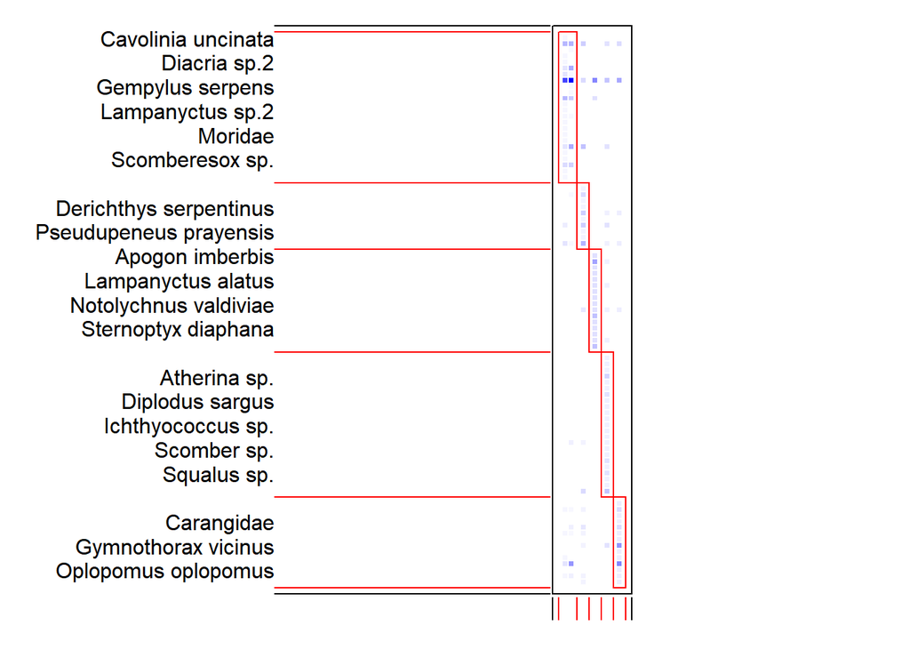

```r
plotModuleWeb(seabirds.net.mod)
```

### 2.3.3 Comparisons of Network level metrics with Null model

Null model:

```r
nulls <- nullmodel(seabirds.network$caboverde, N= 1000, method = "vaznull")
```

- **weighted NODF**:

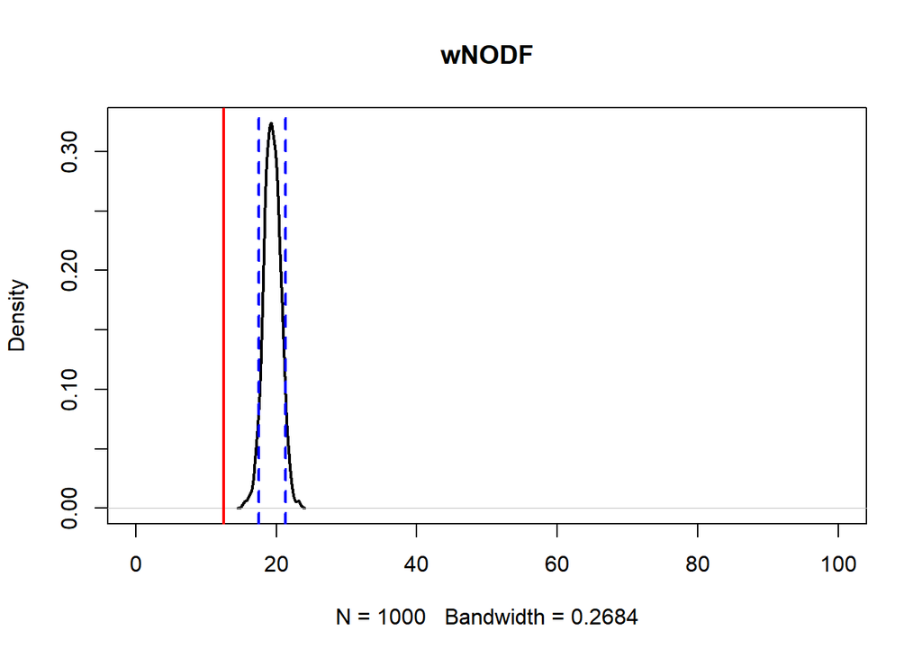

```r
obs_wNODF <- network_indeces[1]

nulls_wNODF <- sapply(nulls, function(x) networklevel(x, index = "weighted NODF")[1])
plot(density(nulls_wNODF), xlim=c(0, 100), lwd=2, main="wNODF")
abline(v=c(quantile(nulls_wNODF, 0.05), quantile(nulls_wNODF, 0.95), obs_wNODF), col=c("blue","blue", "red"), lty=c(2,2,1), lwd=c(2,2,2))
```

- **H2**:

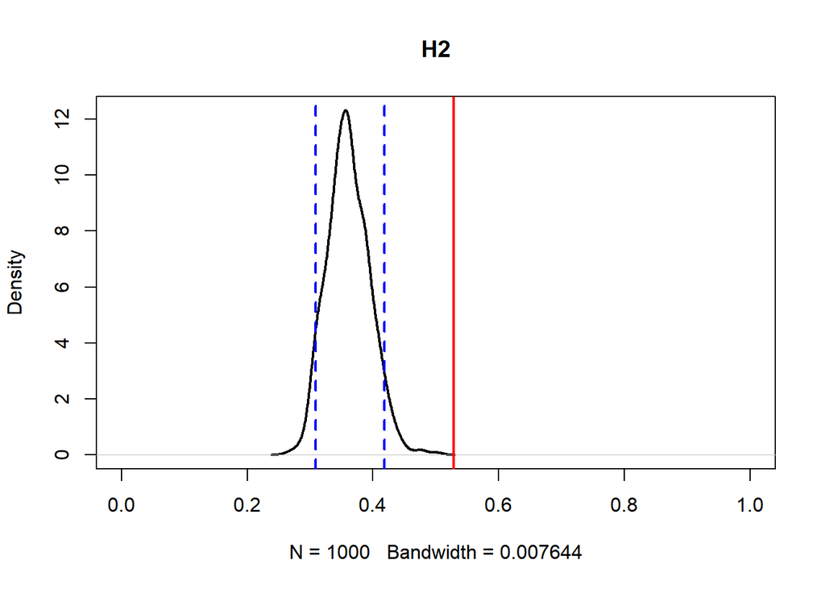

```r
obs_H2 <- network_indeces[2]

nulls_H2 <- sapply(nulls, function(x) networklevel(x, index = "H2")[1])
plot(density(nulls_H2), xlim=c(0, 1), lwd=2, main="H2")
abline(v=c(quantile(nulls_H2, 0.05), quantile(nulls_H2, 0.95), obs_H2), col=c("blue","blue", "red"), lty=c(2,2,1), lwd=c(2,2,2))
```

- **Modularity**:

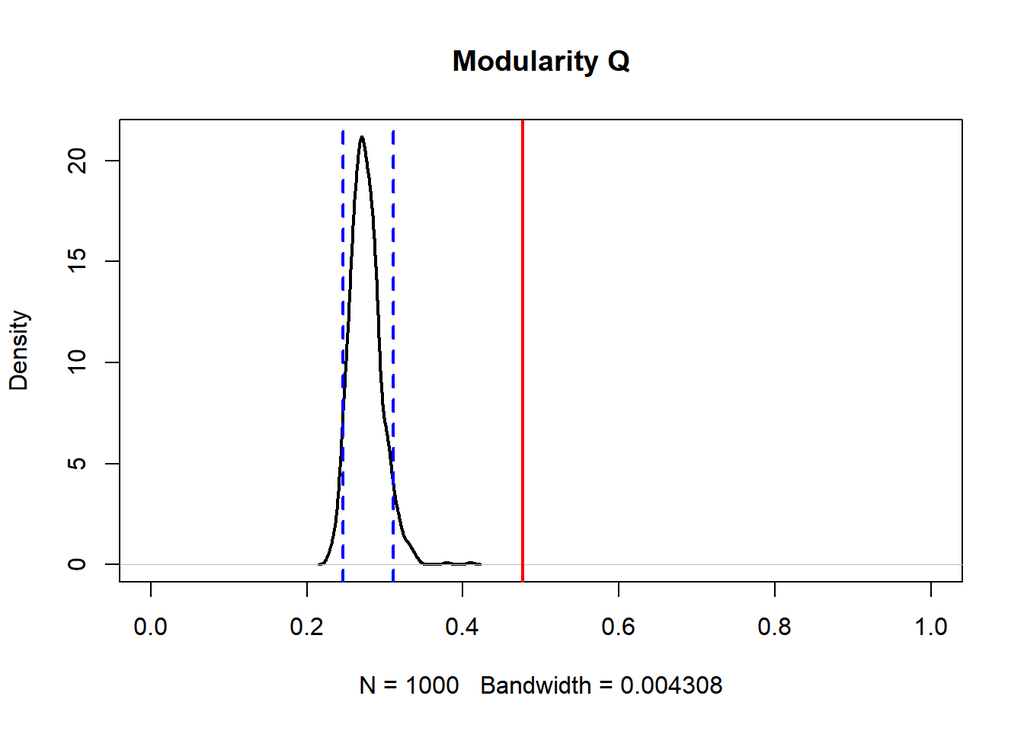

```r
nulls_Q <- sapply(nulls, function(x) metaComputeModules(x)@likelihood)

plot(density(nulls_Q), xlim=c(0, 1), lwd=2, main="Modularity Q")
abline(v=c(quantile(nulls_Q, 0.05), quantile(nulls_Q, 0.95), obs_Q), col=c("blue","blue", "red"), lty=c(2,2,1), lwd=c(2,2,2))
```

### 2.3.4 Module based metrices (Cz-values)

```r
seabirds.HL.cz <- czvalues(seabirds.net.mod)
seabirds.HL.cz <- as.data.frame(seabirds.HL.cz) %>% mutate_if(is.numeric, replace_na, 0)

seabirds.LL.cz <- czvalues(seabirds.net.mod, level = "lower")
seabirds.LL.cz <- as.data.frame(seabirds.LL.cz) %>% mutate_if(is.numeric, replace_na, 0)

seabirds.HL.cz
```

|  | c | z |
| --- | --- | --- |
| BB | 0.5121107 | 0.0000000 |
| CE | 0.6900826 | 0.0000000 |
| HJ | 0.1975309 | 0.0000000 |
| PA | 0.4005102 | 0.7071068 |
| PB | 0.4321330 | 0.0000000 |
| SL | 0.5817175 | -0.7071068 |

```r
seabirds.LL.cz
```

|  | c | z |
| --- | --- | --- |
| Acanthuridae | 0.0000000 | 0.0000000 |
| Acanthurus sp. | 0.0000000 | 0.0000000 |
| Apletodon sp. | 0.0000000 | 0.0000000 |
| Apogon imberbis | 0.0000000 | 0.0000000 |
| Argyropelecus sladeni | 0.5000000 | 0.0000000 |
| Arothron sp. | 0.6250000 | 0.0000000 |
| Assimineidae | 0.0000000 | 0.0000000 |
| Asthenognathus atlanticus | 0.0000000 | 0.0000000 |
| Atherina sp. | 0.0000000 | 0.0000000 |
| Brotula sp. | 0.0000000 | 0.0000000 |
| Carangidae | 0.0000000 | 0.0000000 |
| Cavolinia uncinata | 0.0000000 | -0.6922187 |
| Cephalopholis sp. | 0.6666667 | 0.0000000 |
| Ceratoscopelus sp. | 0.0000000 | 0.0000000 |
| Chelon auratus | 0.0000000 | 0.0000000 |
| Chromis chromis | 0.7200000 | 1.3844373 |
| Conger conger | 0.0000000 | 0.0000000 |
| Coryphaena equiselis | 0.5000000 | 0.0000000 |
| Cyclothone pallida | 0.0000000 | 0.0000000 |
| Decapterus macarellus | 0.6250000 | 0.0000000 |
| Decapterus punctactus | 0.0000000 | -0.6922187 |
| Derichthys serpentinus | 0.0000000 | 0.0000000 |
| Diacria sp.1 | 0.0000000 | -0.6922187 |
| Diacria sp.2 | 0.0000000 | -0.6922187 |
| Diaphus dumerilli | 0.0000000 | 0.0000000 |
| Diplodus sargus | 0.0000000 | 0.0000000 |
| Diplodus vulgaris | 0.0000000 | 0.0000000 |
| Engraulis encrasicolus | 0.6666667 | 0.0000000 |
| Engraulis sp. | 0.0000000 | 0.0000000 |
| Exocoetidae | 0.0000000 | 0.0000000 |

[output cut: 57 more lines]

### 2.3.5 Comparisons of Module based metrics with Null model:

Null model cz-values:

```r
nulls_cvalues_HL <- sapply(nulls, function(x) czvalues(metaComputeModules(x))$c)
quantile(nulls_cvalues_HL, 0.95)
```

```
##       95%
## 0.6648199
```

```r
nulls_zvalues_HL <- sapply(nulls, function(x) czvalues(metaComputeModules(x))$z)
nulls_zvalues_HL[is.na(nulls_zvalues_HL)] <- 0
quantile(nulls_zvalues_HL, 0.95)
```

```
##       95%
## 0.7071068
```

```r
nulls_cvalues_LL <- sapply(nulls, function(x) czvalues(metaComputeModules(x), level = "lower")$c)
quantile(nulls_cvalues_LL, 0.95)
```

```
##       95%
## 0.6666667
```

```r
nulls_zvalues_LL <- sapply(nulls, function(x) czvalues(metaComputeModules(x), level = "lower")$z)
nulls_zvalues_LL[is.na(nulls_zvalues_LL)] <- 0
quantile(nulls_zvalues_LL, 0.95)
```

```
##     95%
## 1.70084
```

Plots

- **Higher level**

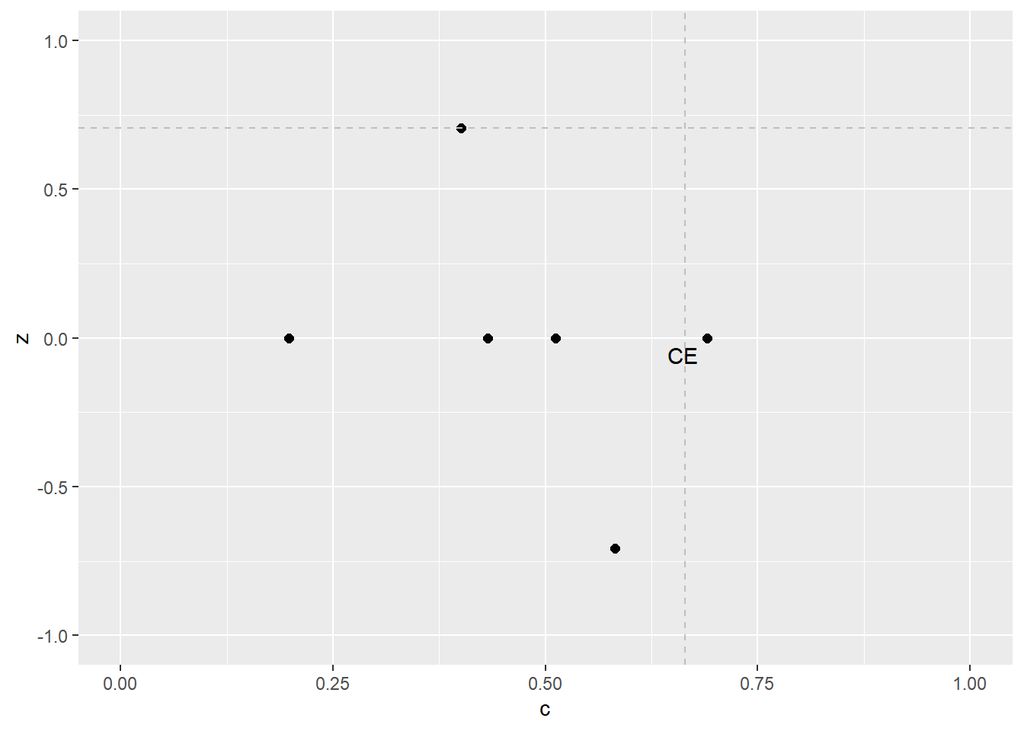

```r
HL_czplot <- ggplot(seabirds.HL.cz, aes(x=c, y=z)) +
  xlim(0, 1) +
  ylim(-1, 1) +
  geom_point(size = 2) +
  geom_vline(xintercept = quantile(nulls_cvalues_HL, 0.95), linetype="dashed", color = "grey") +
  geom_hline(yintercept = quantile(nulls_zvalues_HL, 0.95), linetype="dashed", color = "grey") +
  geom_text_repel(data=subset(seabirds.HL.cz, c > quantile(nulls_cvalues_HL, 0.95) | z > quantile(nulls_zvalues_HL, 0.95)), aes(label = row.names(subset(seabirds.HL.cz, c > quantile(nulls_cvalues_HL, 0.95) | z > quantile(nulls_zvalues_HL, 0.95)))))

HL_czplot
```

- **Lower level**

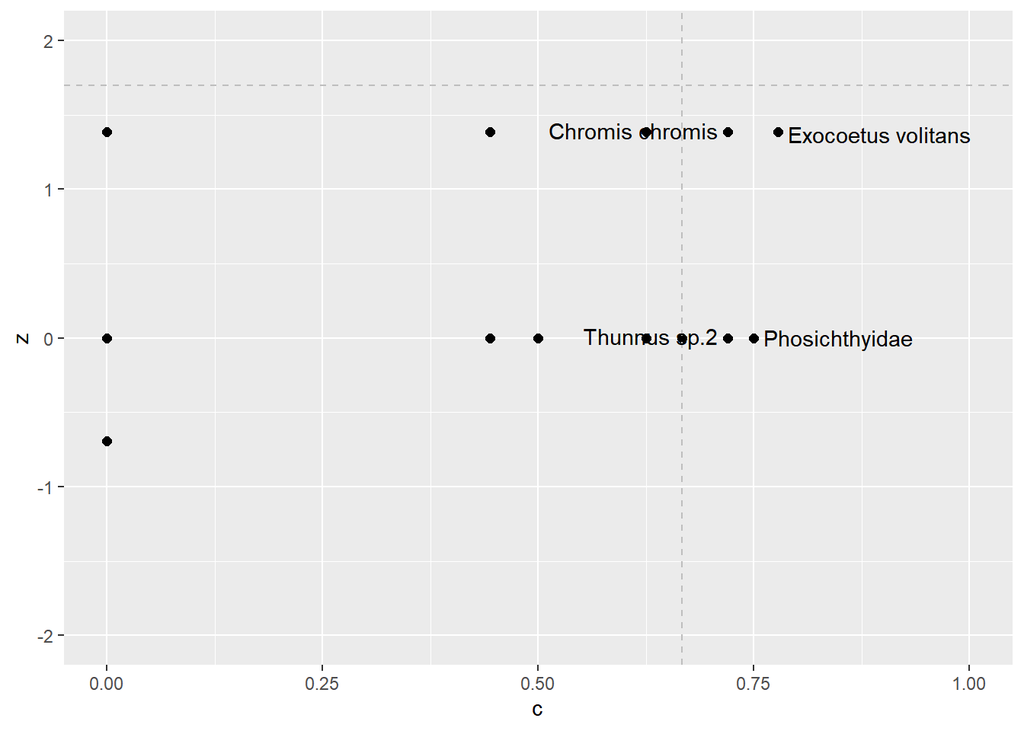

```r
LL_czplot <- ggplot(seabirds.LL.cz, aes(x=c, y=z)) +
  xlim(0, 1) +
  ylim(-2, 2) +
  geom_point(size = 2) +
  geom_vline(xintercept = quantile(nulls_cvalues_LL, 0.95), linetype="dashed", color = "grey") +
  geom_hline(yintercept = quantile(nulls_zvalues_LL, 0.95), linetype="dashed", color = "grey") +
  geom_text_repel(data=subset(seabirds.LL.cz, c > quantile(nulls_cvalues_LL, 0.95) | z > quantile(nulls_zvalues_LL, 0.95)), aes(label = row.names(subset(seabirds.LL.cz, c > quantile(nulls_cvalues_LL, 0.95) | z > quantile(nulls_zvalues_LL, 0.95)))))

LL_czplot
```

## 2.4 Network analysis using FI

In this analysis, an interaction network from the whole MOTU matrix was built using the Frequency of Interaction (FI) to index the strength of interactions. Then, we used several metrics to quantify several key characteristics of the network.

```r
seabirds.net.matrix <- sample.matrix.motu.long.good[,c(1,2,4)] %>% filter(present > 0) %>% dplyr::rename(higher = host_species, lower = Species, freq = present)
seabirds.net.matrix$webID = "caboverde"
seabirds.net.matrix <- seabirds.net.matrix[, c(1, 2, 4, 3)]

seq.high <- as.data.frame(seabirds.net.matrix$higher)%>% dplyr::rename(seq.high = "seabirds.net.matrix$higher") %>% distinct(seq.high)
seq.low <- as.data.frame(seabirds.net.matrix$lower)%>% dplyr::rename(seq.low = "seabirds.net.matrix$lower") %>% distinct(seq.low)

seabirds.network <- frame2webs(data.frame(seabirds.net.matrix),type.out="list")
```

### 2.4.1 Species level metrics

```r
species_indeces <- specieslevel(seabirds.network$caboverde, index=c("normalised degree", "d"))
species_indeces
```

```
## $`higher level`
##    normalised.degree         d
## BB         0.3908046 0.5227892
## CE         0.2528736 0.4007634
## HJ         0.2068966 0.6752765
## PA         0.3218391 0.2454696
## PB         0.2183908 0.3884939
## SL         0.2183908 0.2842642
##
## $`lower level`
##                               normalised.degree          d
## Acanthuridae                          0.1666667 0.22878755
## Acanthurus sp.                        0.1666667 0.16879299
## Apletodon sp.                         0.1666667 0.16879299
## Apogon imberbis                       0.1666667 0.31251909
## Argyropelecus sladeni                 0.3333333 0.38884832
## Arothron sp.                          0.6666667 0.08177823
## Assimineidae                          0.1666667 0.16879299
## Asthenognathus atlanticus             0.1666667 0.22878755
## Atherina sp.                          0.1666667 0.35065256
## Brotula sp.                           0.1666667 0.16879299
## Carangidae                            0.1666667 0.22878755
## Cavolinia uncinata                    0.1666667 0.07505084
## Cephalopholis sp.                     0.5000000 0.14833749
## Ceratoscopelus sp.                    0.1666667 0.16879299
## Chelon auratus                        0.1666667 0.29019834
## Chromis chromis                       0.8333333 0.04486612
## Conger conger                         0.1666667 0.17319682
## Coryphaena equiselis                  0.3333333 0.22508430
## Cyclothone pallida                    0.1666667 0.17319682
## Decapterus macarellus                 0.6666667 0.01674441
## Decapterus punctactus                 0.1666667 0.00000000
## Derichthys serpentinus                0.1666667 0.17319682
## Diacria sp.1                          0.1666667 0.07505084
## Diacria sp.2                          0.1666667 0.07505084
## Diaphus dumerilli                     0.1666667 0.31251909
## Diplodus sargus                       0.1666667 0.16879299
## Diplodus vulgaris                     0.1666667 0.16879299
## Engraulis encrasicolus                0.5000000 0.26349578
## Engraulis sp.                         0.1666667 0.16879299
```

[output cut: 43 more lines]

```
## Solea senegalensis                    0.1666667 0.16879299
## Sparidae 1                            0.1666667 0.29019834
## Sparidae 2                            0.1666667 0.16879299
## Squalus sp.                           0.1666667 0.29019834
## Sternoptyx diaphana                   0.1666667 0.31251909
## Sternoptyx pseudodiaphana             0.1666667 0.31251909
## Sternoptyx pseudopallida              0.3333333 0.21105037
## Sthenoteuthis pteropus                0.1666667 0.07505084
## Stomiidae                             0.1666667 0.17319682
## Stylephorus chordatus                 0.1666667 0.43952810
## Symphodus bailloni                    0.1666667 0.16879299
## Symphodus melops                      0.1666667 0.16879299
## Thunnus sp.1                          0.3333333 0.31825888
## Thunnus sp.2                          0.8333333 0.14194892
## Trichiuridae                          0.1666667 0.07505084
```

### 2.4.2 Network level metrics

- **Network indeces**:

```r
network_indeces <- networklevel(seabirds.network$caboverde, index = c("weighted NODF", "H2"))
network_indeces
```

```
## weighted NODF            H2
##    12.5210912     0.3533386
```

- **Modularity**:

```r
seabirds.net.mod <- metaComputeModules(seabirds.network$caboverde, N=500)
obs_Q <- seabirds.net.mod@likelihood
obs_Q
```

```
## [1] 0.3907556
```

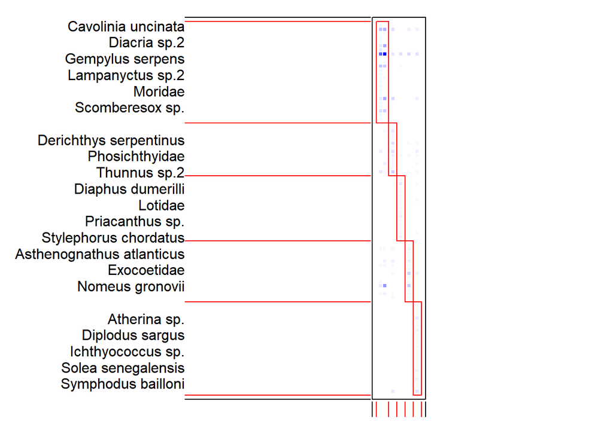

```r
plotModuleWeb(seabirds.net.mod)
```

### 2.4.3 Comparisons of Network level metrics with Null model

Null model:

```r
nulls <- nullmodel(seabirds.network$caboverde, N= 1000, method = "vaznull")
```

- **weighted NODF**:

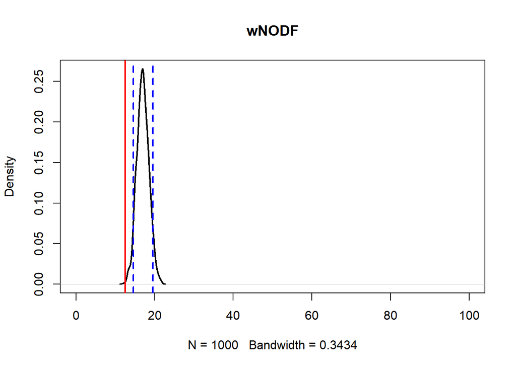

```r
obs_wNODF <- network_indeces[1]

nulls_wNODF <- sapply(nulls, function(x) networklevel(x, index = "weighted NODF")[1])
plot(density(nulls_wNODF), xlim=c(0, 100), lwd=2, main="wNODF")
abline(v=c(quantile(nulls_wNODF, 0.05), quantile(nulls_wNODF, 0.95), obs_wNODF), col=c("blue","blue", "red"), lty=c(2,2,1), lwd=c(2,2,2))
```

- **H2**:

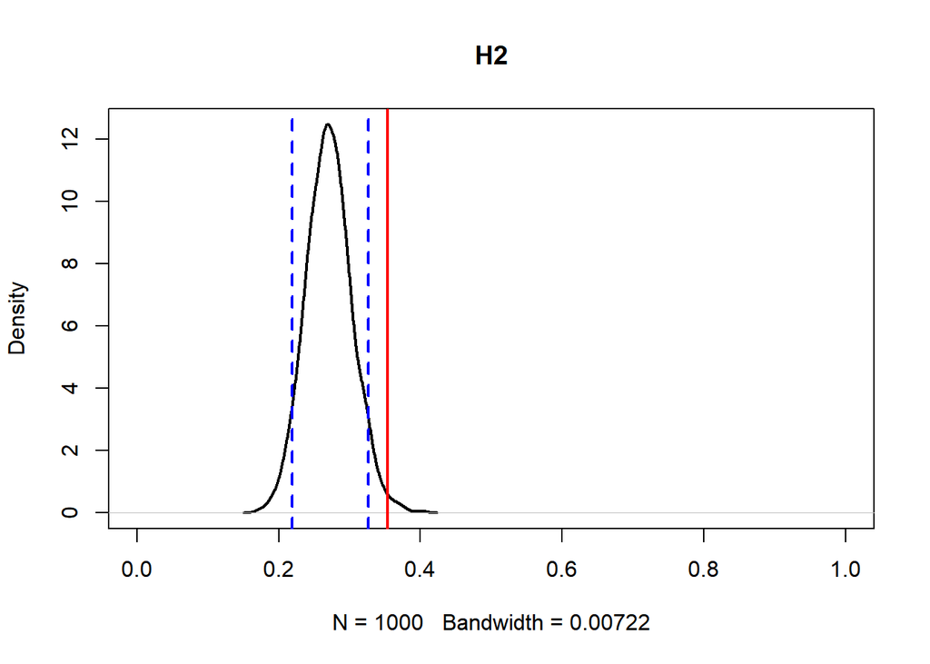

```r
obs_H2 <- network_indeces[2]

nulls_H2 <- sapply(nulls, function(x) networklevel(x, index = "H2")[1])
plot(density(nulls_H2), xlim=c(0, 1), lwd=2, main="H2")
abline(v=c(quantile(nulls_H2, 0.05), quantile(nulls_H2, 0.95), obs_H2), col=c("blue","blue", "red"), lty=c(2,2,1), lwd=c(2,2,2))
```

- **Modularity**:

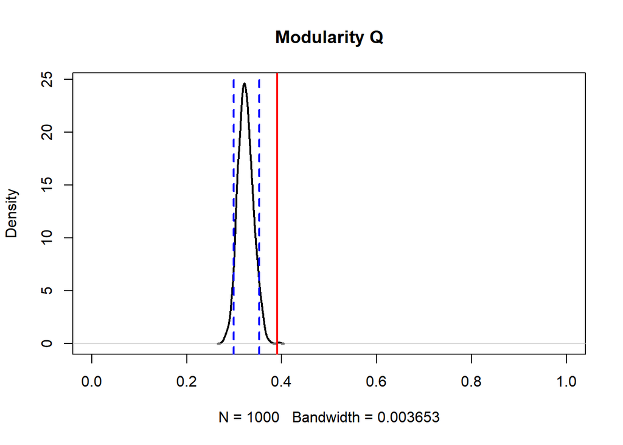

```r
nulls_Q <- sapply(nulls, function(x) metaComputeModules(x)@likelihood)

plot(density(nulls_Q), xlim=c(0, 1), lwd=2, main="Modularity Q")
abline(v=c(quantile(nulls_Q, 0.05), quantile(nulls_Q, 0.95), obs_Q), col=c("blue","blue", "red"), lty=c(2,2,1), lwd=c(2,2,2))
```

### 2.4.4 Module based metrices (Cz-values)

```r
seabirds.HL.cz <- czvalues(seabirds.net.mod)
seabirds.HL.cz <- as.data.frame(seabirds.HL.cz) %>% mutate_if(is.numeric, replace_na, 0)

seabirds.LL.cz <- czvalues(seabirds.net.mod, level = "lower")
seabirds.LL.cz <- as.data.frame(seabirds.LL.cz) %>% mutate_if(is.numeric, replace_na, 0)

seabirds.HL.cz
```

|  | c | z |
| --- | --- | --- |
| BB | 0.5432526 | 0.0000000 |
| CE | 0.6074380 | 0.0000000 |
| HJ | 0.2901235 | 0.0000000 |
| PA | 0.4005102 | 0.7071068 |
| PB | 0.4210526 | 0.0000000 |
| SL | 0.5706371 | -0.7071068 |

```r
seabirds.LL.cz
```

|  | c | z |
| --- | --- | --- |
| Acanthuridae | 0.0000000 | 0.0000000 |
| Acanthurus sp. | 0.0000000 | 0.0000000 |
| Apletodon sp. | 0.0000000 | 0.0000000 |
| Apogon imberbis | 0.0000000 | 0.0000000 |
| Argyropelecus sladeni | 0.5000000 | 0.0000000 |
| Arothron sp. | 0.6250000 | 0.0000000 |
| Assimineidae | 0.0000000 | 0.0000000 |
| Asthenognathus atlanticus | 0.0000000 | 0.0000000 |
| Atherina sp. | 0.0000000 | 0.0000000 |
| Brotula sp. | 0.0000000 | 0.0000000 |
| Carangidae | 0.0000000 | 0.0000000 |
| Cavolinia uncinata | 0.0000000 | -0.6922187 |
| Cephalopholis sp. | 0.6666667 | 0.0000000 |
| Ceratoscopelus sp. | 0.0000000 | 0.0000000 |
| Chelon auratus | 0.0000000 | 0.0000000 |
| Chromis chromis | 0.7200000 | 1.3844373 |
| Conger conger | 0.0000000 | 0.0000000 |
| Coryphaena equiselis | 0.5000000 | 0.0000000 |
| Cyclothone pallida | 0.0000000 | 0.0000000 |
| Decapterus macarellus | 0.6250000 | 0.0000000 |
| Decapterus punctactus | 0.0000000 | -0.6922187 |
| Derichthys serpentinus | 0.0000000 | 0.0000000 |
| Diacria sp.1 | 0.0000000 | -0.6922187 |
| Diacria sp.2 | 0.0000000 | -0.6922187 |
| Diaphus dumerilli | 0.0000000 | 0.0000000 |
| Diplodus sargus | 0.0000000 | 0.0000000 |
| Diplodus vulgaris | 0.0000000 | 0.0000000 |
| Engraulis encrasicolus | 0.6666667 | 0.0000000 |
| Engraulis sp. | 0.0000000 | 0.0000000 |
| Exocoetidae | 0.0000000 | 0.0000000 |

[output cut: 57 more lines]

### 2.4.5 Comparisons of Module based metrics with Null model:

Null model cz-values:

```r
nulls_cvalues_HL <- sapply(nulls, function(x) czvalues(metaComputeModules(x))$c)
quantile(nulls_cvalues_HL, 0.95)
```

```
##       95%
## 0.6796907
```

```r
nulls_zvalues_HL <- sapply(nulls, function(x) czvalues(metaComputeModules(x))$z)
nulls_zvalues_HL[is.na(nulls_zvalues_HL)] <- 0
quantile(nulls_zvalues_HL, 0.95)
```

```
##       95%
## 0.7071068
```

```r
nulls_cvalues_LL <- sapply(nulls, function(x) czvalues(metaComputeModules(x), level = "lower")$c)
quantile(nulls_cvalues_LL, 0.95)
```

```
##  95%
## 0.72
```

```r
nulls_zvalues_LL <- sapply(nulls, function(x) czvalues(metaComputeModules(x), level = "lower")$z)
nulls_zvalues_LL[is.na(nulls_zvalues_LL)] <- 0
quantile(nulls_zvalues_LL, 0.95)
```

```
## 95%
##   0
```

Plots

- **Higher level**

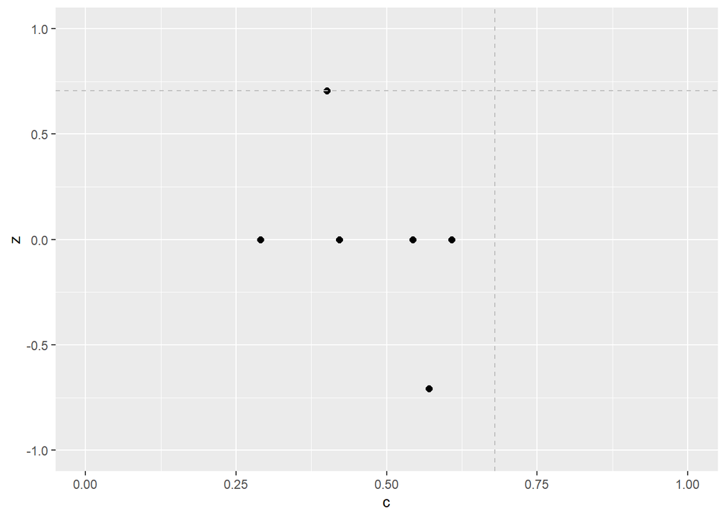

```r
HL_czplot <- ggplot(seabirds.HL.cz, aes(x=c, y=z)) +
  xlim(0, 1) +
  ylim(-1, 1) +
  geom_point(size = 2) +
  geom_vline(xintercept = quantile(nulls_cvalues_HL, 0.95), linetype="dashed", color = "grey") +
  geom_hline(yintercept = quantile(nulls_zvalues_HL, 0.95), linetype="dashed", color = "grey") +
  geom_text_repel(data=subset(seabirds.HL.cz, c > quantile(nulls_cvalues_HL, 0.95) | z > quantile(nulls_zvalues_HL, 0.95)), aes(label = row.names(subset(seabirds.HL.cz, c > quantile(nulls_cvalues_HL, 0.95) | z > quantile(nulls_zvalues_HL, 0.95)))))

HL_czplot
```

- **Lower level**

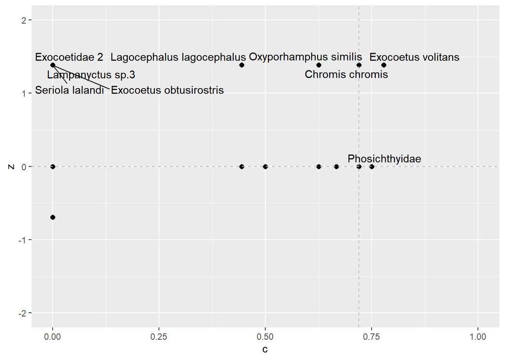

```r
LL_czplot <- ggplot(seabirds.LL.cz, aes(x=c, y=z)) +
  xlim(0, 1) +
  ylim(-2, 2) +
  geom_point(size = 2) +
  geom_vline(xintercept = quantile(nulls_cvalues_LL, 0.95), linetype="dashed", color = "grey") +
  geom_hline(yintercept = quantile(nulls_zvalues_LL, 0.95), linetype="dashed", color = "grey") +
  geom_text_repel(data=subset(seabirds.LL.cz, c > quantile(nulls_cvalues_LL, 0.95) | z > quantile(nulls_zvalues_LL, 0.95)), aes(label = row.names(subset(seabirds.LL.cz, c > quantile(nulls_cvalues_LL, 0.95) | z > quantile(nulls_zvalues_LL, 0.95)))))

LL_czplot
```

## 2.5 NMDS

A NMDS was made to verify if the data had outliers

```r
set.seed(123)
nmds.jaccard.motu = metaMDS(PA.matrix.motu, distance = "jaccard", binary=T)
```

```
## *** No convergence -- monoMDS stopping criteria:
##     20: no. of iterations >= maxit
```

```r
nmds.jaccard.motu
```

```
##
## Call:
## metaMDS(comm = PA.matrix.motu, distance = "jaccard", binary = T)
##
## global Multidimensional Scaling using monoMDS
##
## Data:     PA.matrix.motu
## Distance: binary jaccard
##
## Dimensions: 2
## Stress:     0.0006337354
## Stress type 1, weak ties
## No convergent solutions - best solution after 20 tries
## Scaling: centring, PC rotation, halfchange scaling
## Species: expanded scores based on 'PA.matrix.motu'
```

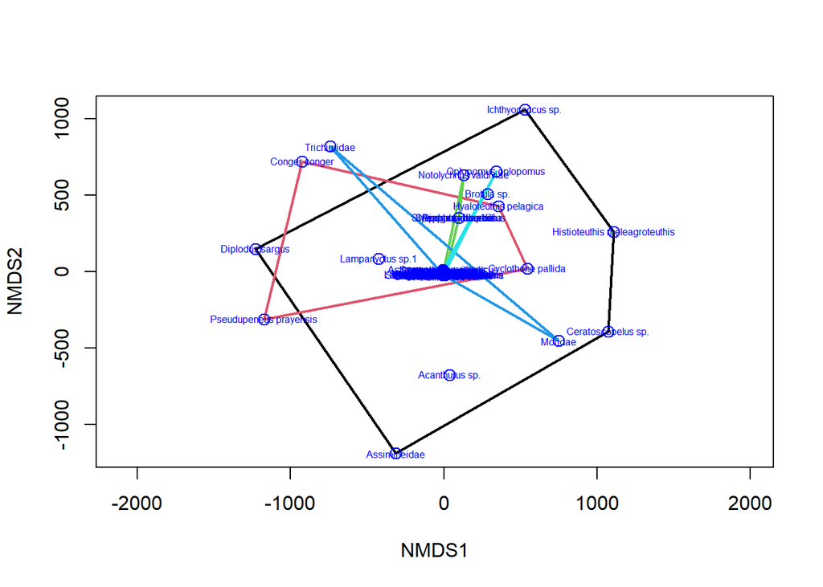

```r
attach(factors.ord)

plot(nmds.jaccard.motu, display = "sites", type="n")
ordihull(nmds.jaccard.motu, host_species, col=1:6, conf = 0.95, lwd=2)
points(nmds.jaccard.motu, disp="species", col="blue", pch=21, cex=1.3)
text(nmds.jaccard.motu, display = "species", cex=0.5, col="blue")
```

```r
detach(factors.ord)
```

> **Several outliers were detected, which are singletons:** such MOTU only appears in one sample, and those samples only have this MOTU

> The analysis continued without these outliers.

> New dataframes were build, both MOTU matrix and factor matrix.

```r
motu_outliers <- c("BUBU_18_RA_37", "BUBU_18_RA_57", "BUBU_19_IC_02", "BUBU_19_IC_03", "BUBU_19_RA_15", "BUBU_19_RA_18", "BUBU_19_RA_19", "BUBU_19_RA_25", "CAED_18_CV_03", "CAED_18_CV_07", "CAED_18_RA_16", "CAED_18_RA_21", "HYJA_19_RA_02", "HYJA_19_RA_03", "HYJA_19_RA_05", "PHAE_18_CD_02", "PHAE_18_SG_06", "PUBO_19_IC_23")

data_seabirds.no_outliers.motu <- subset(data_seabirds, !(Extraction_ID %in% motu_outliers))

PA.matrix.motu.no_outliers <- dcast(data_seabirds.no_outliers.motu, Extraction_ID ~ final_id, function(x) if(length(x)>=1) 1 else 0, value.var = "final_id")
PA.matrix.motu.no_outliers2 <- PA.matrix.motu.no_outliers %>% remove_rownames %>% column_to_rownames(var="Extraction_ID")

factors.no_outliers <- data_seabirds.no_outliers.motu %>% dplyr::select(Extraction_ID, host_species, Year, Guild, Site, season, host_season) %>% distinct(Extraction_ID, .keep_all = TRUE)
factors.no_outliers[] <- lapply(factors.no_outliers[colnames(factors.no_outliers)], as.factor)

factors.no_outliers.ord <- factors.no_outliers[order(factors.no_outliers$Extraction_ID),] %>% remove_rownames %>% column_to_rownames(var="Extraction_ID")
```

## 2.6 Test similarity between prey matrix - MVABUND

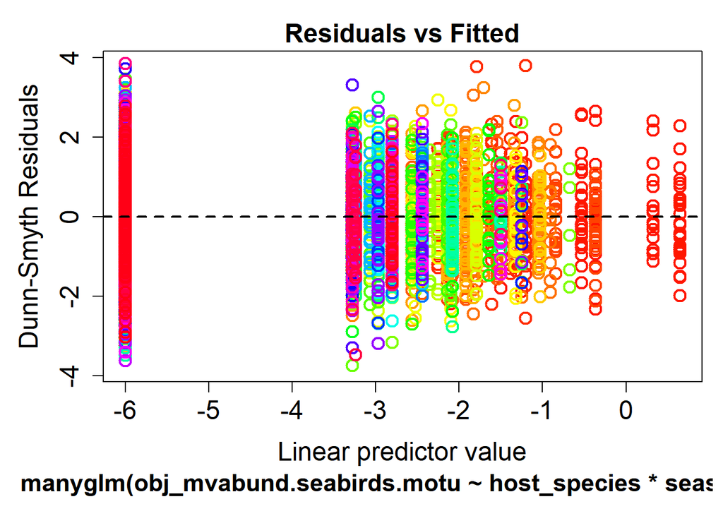

```r
mvabund.seabirds.motu <- merge(PA.matrix.motu.no_outliers, factors.no_outliers)
mvabund.seabirds.motu <- mvabund.seabirds.motu[order(mvabund.seabirds.motu$host_species),]


obj_mvabund.seabirds.motu <- mvabund(mvabund.seabirds.motu[,2:68])
fact_mvabund.seabirds.motu <- mvabund.seabirds.motu[, 69:74]

cloglog_mvabund.seabirds.motu <- manyglm(obj_mvabund.seabirds.motu ~ host_species * season, data = fact_mvabund.seabirds.motu, family="cloglog")

plot(cloglog_mvabund.seabirds.motu)
```

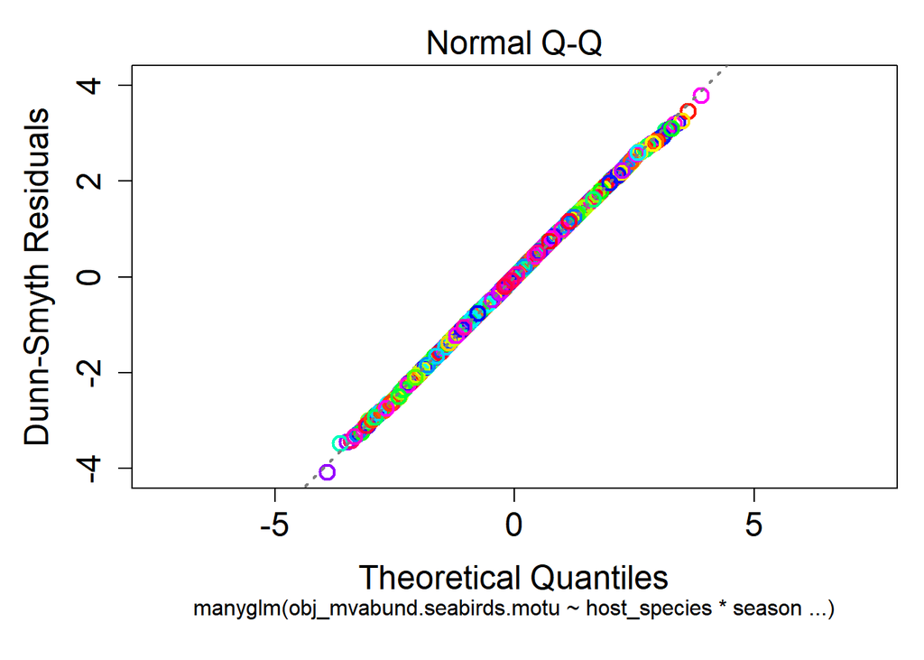

```r
plot(cloglog_mvabund.seabirds.motu, which = 2)
```

### 2.6.1 Model selection

```r
drop1(cloglog_mvabund.seabirds.motu)
```

|  | Df | AIC |
| --- | --- | --- |
|  | NA | 3128.309 |
| host_species:season | 268 | 2609.485 |

```r
x <- c(drop1(cloglog_mvabund.seabirds.motu)[[2]] > min(drop1(cloglog_mvabund.seabirds.motu)[[2]]))
y <- rownames(drop1(cloglog_mvabund.seabirds.motu))
y[!x]
```

```
## [1] "host_species:season"
```

```r
cloglog_mvabund.seabirds.motu2 <- update(cloglog_mvabund.seabirds.motu, .~. - host_species:season)

anova(cloglog_mvabund.seabirds.motu2, cloglog_mvabund.seabirds.motu, nBoot=1000)
```

```
## Time elapsed: 0 hr 2 min 45 sec
```

```
## Analysis of Deviance Table
##
## cloglog_mvabund.seabirds.motu2: obj_mvabund.seabirds.motu ~ host_species + season
## cloglog_mvabund.seabirds.motu: obj_mvabund.seabirds.motu ~ host_species * season
##
## Multivariate test:
##                                Res.Df Df.diff   Dev Pr(>Dev)
## cloglog_mvabund.seabirds.motu2    153
## cloglog_mvabund.seabirds.motu     151       2 17.18    0.258
## Arguments:
##  Test statistics calculated assuming uncorrelated response (for faster computation)
##  P-value calculated using 1000 iterations via PIT-trap resampling.
```

```r
#There are no significant differences between the models, so we keep dropping factors from the model with lower AIC: mod2

drop1(cloglog_mvabund.seabirds.motu2)
```

|  | Df | AIC |
| --- | --- | --- |
|  | NA | 2609.485 |
| host_species | 335 | 2392.186 |
| season | 67 | 2557.208 |

```r
x <- c(drop1(cloglog_mvabund.seabirds.motu2)[[2]] > min(drop1(cloglog_mvabund.seabirds.motu2)[[2]]))
y <- rownames(drop1(cloglog_mvabund.seabirds.motu2))
y[!x]
```

```
## [1] "host_species"
```

```r
cloglog_mvabund.seabirds.motu3 <- update(cloglog_mvabund.seabirds.motu2, .~. - host_species)

anova(cloglog_mvabund.seabirds.motu3, cloglog_mvabund.seabirds.motu2, nBoot=1000)
```

```
## Time elapsed: 0 hr 3 min 59 sec
```

```
## Analysis of Deviance Table
##
## cloglog_mvabund.seabirds.motu3: obj_mvabund.seabirds.motu ~ season
## cloglog_mvabund.seabirds.motu2: obj_mvabund.seabirds.motu ~ host_species + season
##
## Multivariate test:
##                                Res.Df Df.diff   Dev Pr(>Dev)
## cloglog_mvabund.seabirds.motu3    158
## cloglog_mvabund.seabirds.motu2    153       5 344.4    0.001 ***
## ---
## Signif. codes:  0 '***' 0.001 '**' 0.01 '*' 0.05 '.' 0.1 ' ' 1
## Arguments:
##  Test statistics calculated assuming uncorrelated response (for faster computation)
##  P-value calculated using 1000 iterations via PIT-trap resampling.
```

```r
#host_species is an important factor to the model, so we will try to drop the other factor

cloglog_mvabund.seabirds.motu4 <- update(cloglog_mvabund.seabirds.motu2, .~. - season)

anova(cloglog_mvabund.seabirds.motu4, cloglog_mvabund.seabirds.motu2, nBoot=1000)
```

```
## Time elapsed: 0 hr 2 min 44 sec
```

```
## Analysis of Deviance Table
##
## cloglog_mvabund.seabirds.motu4: obj_mvabund.seabirds.motu ~ host_species
## cloglog_mvabund.seabirds.motu2: obj_mvabund.seabirds.motu ~ host_species + season
##
## Multivariate test:
##                                Res.Df Df.diff   Dev Pr(>Dev)
## cloglog_mvabund.seabirds.motu4    154
## cloglog_mvabund.seabirds.motu2    153       1 81.72    0.001 ***
## ---
## Signif. codes:  0 '***' 0.001 '**' 0.01 '*' 0.05 '.' 0.1 ' ' 1
## Arguments:
##  Test statistics calculated assuming uncorrelated response (for faster computation)
##  P-value calculated using 1000 iterations via PIT-trap resampling.
```

Since both *host_species* and *season* are significant factors, we continue with the model 2:

**cloglog_mvabund.seabirds.motu2 (~ host_species + season)**

### 2.6.2 ANOVA

```r
set.seed(123)
anova.mod.motu <- anova(cloglog_mvabund.seabirds.motu2, p.uni="adjusted", nBoot=1000)
```

```
## Time elapsed: 0 hr 6 min 38 sec
```

```r
anova.mod.motu
```

```
## Analysis of Deviance Table
##
## Model: obj_mvabund.seabirds.motu ~ host_species + season
##
## Multivariate test:
##              Res.Df Df.diff    Dev Pr(>Dev)
## (Intercept)     159
## host_species    154       5 292.84    0.002 **
## season          153       1  81.72    0.001 ***
## ---
## Signif. codes:  0 '***' 0.001 '**' 0.01 '*' 0.05 '.' 0.1 ' ' 1
##
## Univariate Tests:
##              Acanthuridae          Apletodon.sp.          Argyropelecus.sladeni
##                       Dev Pr(>Dev)           Dev Pr(>Dev)                   Dev
## (Intercept)
## host_species            0    1.000             0    1.000                     0
## season                  0    1.000             0    1.000                 0.228
##                       Arothron.sp.          Asthenognathus.atlanticus
##              Pr(>Dev)          Dev Pr(>Dev)                       Dev Pr(>Dev)
## (Intercept)
## host_species    1.000        3.955    1.000                         0    1.000
## season          1.000        0.043    1.000                         0    1.000
##              Atherina.sp.          Carangidae          Cavolinia.uncinata
##                       Dev Pr(>Dev)        Dev Pr(>Dev)                Dev
## (Intercept)
## host_species            0    1.000          0    1.000              2.843
## season                  0    1.000          0    1.000              2.417
##                       Cephalopholis.sp.          Chelon.auratus
##              Pr(>Dev)               Dev Pr(>Dev)            Dev Pr(>Dev)
## (Intercept)
## host_species    1.000             7.356    0.916              0    1.000
## season          0.989             0.022    1.000              0    1.000
##              Chromis.chromis          Coryphaena.equiselis
##                          Dev Pr(>Dev)                  Dev Pr(>Dev)
## (Intercept)
## host_species           5.202    1.000                 9.05    0.662
## season                 0.283    1.000                1.208    1.000
##              Decapterus.macarellus          Decapterus.punctactus
##                                Dev Pr(>Dev)                   Dev Pr(>Dev)
```

[output cut: 106 more lines]

```
## host_species                        0    1.000                  2.843    1.000
## season                          1.274    1.000                  0.747    1.000
##              Stomiidae          Symphodus.bailloni          Symphodus.melops
##                    Dev Pr(>Dev)                Dev Pr(>Dev)              Dev
## (Intercept)
## host_species     3.667    1.000                  0    1.000                0
## season               0    1.000                  0    1.000                0
##                       Thunnus.sp.1          Thunnus.sp.2
##              Pr(>Dev)          Dev Pr(>Dev)          Dev Pr(>Dev)
## (Intercept)
## host_species    1.000       20.352    0.008        10.69    0.373
## season          1.000            0    1.000         0.31    1.000
## Arguments:
##  Test statistics calculated assuming uncorrelated response (for faster computation)
## P-value calculated using 1000 iterations via PIT-trap resampling.
```

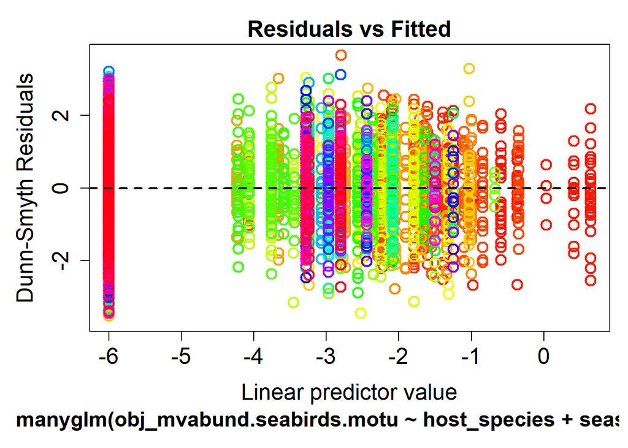

```r
plot(cloglog_mvabund.seabirds.motu2)
```

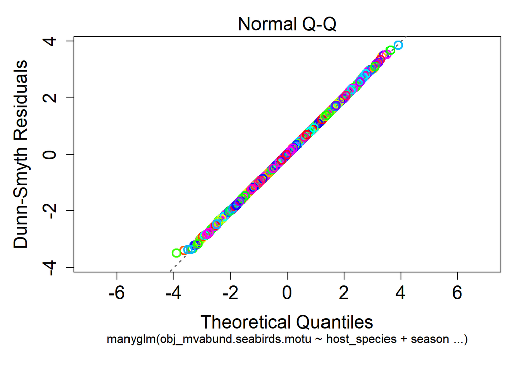

```r
plot(cloglog_mvabund.seabirds.motu2, which = 2)
```

# 3 Data analysis - Seasonal scale

> Populations with smaller sample size than 10 were discarded to avoid poor frequency of occurrence estimates, and therefore HJ samples were not considered for this analysis.

> This resulted on a total of 4 summer populations (CE, BB, SL(S), PA(S)) and 3 winter populations (PB, SL(W), PA(W)).

## 3.1 Matrices

```r
data_seabirds.no_HJ <- subset(data_seabirds, host_species != "HJ")

PA.matrix.motu.no_HJ <- dcast(data_seabirds.no_HJ, Extraction_ID ~ final_id, function(x) if(length(x)>=1) 1 else 0, value.var = "final_id")
PA.matrix.motu.no_HJ2 <- PA.matrix.motu.no_HJ %>% remove_rownames %>% column_to_rownames(var="Extraction_ID")

factors.no_HJ <- data_seabirds.no_HJ %>% dplyr::select(Extraction_ID, host_species, host_season, season) %>% distinct(Extraction_ID, .keep_all = TRUE)
factors.no_HJ[] <- lapply(factors.no_HJ[colnames(factors.no_HJ)], as.factor)

factors.no_HJ.ord <- factors.no_HJ[order(factors.no_HJ$Extraction_ID),] %>% remove_rownames %>% column_to_rownames(var="Extraction_ID")
```

## 3.2 Frequency of Ocurrence (%)

```r
sample.matrix.motu.no_HJ.long <- gather(PA.matrix.motu.no_HJ, Species, Presence, "Acanthuridae":"Trichiuridae", factor_key=TRUE)
sample.matrix.motu.no_HJ.long <- merge(sample.matrix.motu.no_HJ.long, factors.no_HJ)

host_season.matrix.motu.long.good <- ddply(.data = sample.matrix.motu.no_HJ.long, .var = c("host_season", "host_species", "Species"), .fun = summarise,
    n = length(Presence),
    present = sum(Presence %in% c("1")),
    prop = present / n * 100
)

host_season.matrix.motu.wide.good <- host_season.matrix.motu.long.good %>%
  subset(select=c("host_season", "n", "Species", "prop"))%>%
  spread(Species, prop)
host_season.matrix.motu.wide.good <- host_season.matrix.motu.wide.good %>% remove_rownames %>% column_to_rownames(var="host_season")

host_season.matrix.motu.wide.good
```

|  | n | Acanthuridae | Acanthurus sp. | Apletodon sp. | Argyropelecus sladeni | Arothron sp. | Assimineidae | Asthenognathus atlanticus | Atherina sp. | Brotula sp. | Carangidae | Cavolinia uncinata | Cephalopholis sp. | Ceratoscopelus sp. | Chelon auratus | Chromis chromis | Conger conger | Coryphaena equiselis | Cyclothone pallida | Decapterus macarellus | Decapterus punctactus | Derichthys serpentinus | Diacria sp.1 | Diacria sp.2 | Diplodus sargus | Diplodus vulgaris | Engraulis encrasicolus | Engraulis sp. | Exocoetidae | … |
| --- | --- | --- | --- | --- | --- | --- | --- | --- | --- | --- | --- | --- | --- | --- | --- | --- | --- | --- | --- | --- | --- | --- | --- | --- | --- | --- | --- | --- | --- | --- |
| BB_Summer | 25 | 0.000000 | 4 | 4 | 4 | 0.000000 | 4 | 0.000000 | 12 | 4 | 0.000000 | 0.000000 | 0.000000 | 4 | 8 | 8.000000 | 0.000000 | 0.000000 | 0.000000 | 0.000000 | 0.000000 | 0.000000 | 0.000000 | 0.000000 | 4 | 4 | 4.000000 | 4 | 0.000000 | … |
| CE_Summer | 30 | 0.000000 | 0 | 0 | 0 | 3.333333 | 0 | 0.000000 | 0 | 0 | 0.000000 | 0.000000 | 6.666667 | 0 | 0 | 13.333333 | 3.333333 | 10.000000 | 3.333333 | 3.333333 | 0.000000 | 3.333333 | 0.000000 | 0.000000 | 0 | 0 | 13.333333 | 0 | 0.000000 | … |
| PA_Summer | 13 | 0.000000 | 0 | 0 | 0 | 0.000000 | 0 | 0.000000 | 0 | 0 | 0.000000 | 7.692308 | 0.000000 | 0 | 0 | 7.692308 | 0.000000 | 0.000000 | 0.000000 | 7.692308 | 0.000000 | 0.000000 | 7.692308 | 7.692308 | 0 | 0 | 0.000000 | 0 | 0.000000 | … |
| PA_Winter | 28 | 0.000000 | 0 | 0 | 0 | 3.571429 | 0 | 0.000000 | 0 | 0 | 0.000000 | 0.000000 | 0.000000 | 0 | 0 | 25.000000 | 0.000000 | 0.000000 | 0.000000 | 0.000000 | 0.000000 | 0.000000 | 0.000000 | 0.000000 | 0 | 0 | 0.000000 | 0 | 0.000000 | … |
| PB_Winter | 21 | 4.761905 | 0 | 0 | 0 | 9.523810 | 0 | 4.761905 | 0 | 0 | 4.761905 | 0.000000 | 9.523810 | 0 | 0 | 9.523810 | 0.000000 | 0.000000 | 0.000000 | 4.761905 | 0.000000 | 0.000000 | 0.000000 | 0.000000 | 0 | 0 | 4.761905 | 0 | 4.761905 | … |
| SL_Summer | 27 | 0.000000 | 0 | 0 | 0 | 3.703704 | 0 | 0.000000 | 0 | 0 | 0.000000 | 0.000000 | 3.703704 | 0 | 0 | 22.222222 | 0.000000 | 3.703704 | 0.000000 | 0.000000 | 0.000000 | 0.000000 | 0.000000 | 0.000000 | 0 | 0 | 0.000000 | 0 | 0.000000 | … |
| SL_Winter | 22 | 0.000000 | 0 | 0 | 0 | 0.000000 | 0 | 0.000000 | 0 | 0 | 0.000000 | 0.000000 | 4.545454 | 0 | 0 | 18.181818 | 0.000000 | 0.000000 | 0.000000 | 4.545454 | 4.545454 | 0.000000 | 0.000000 | 0.000000 | 0 | 0 | 0.000000 | 0 | 0.000000 | … |

### 3.2.1 Ranked Frequency of Ocurrence (FO) plots

Only the plots for the seasonal populations of continuous breeders were needed, since the curves for the other species were already built in the Community level analysis.

Plots

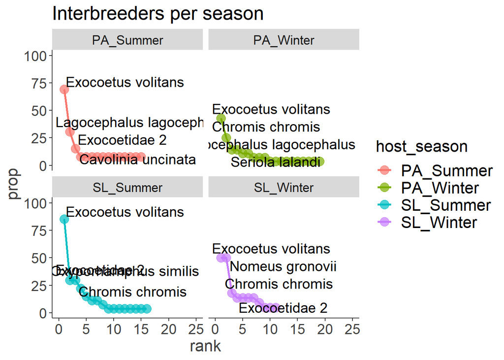

```r
FOplot.inter_seasons <- ggplot(data=FO_plot_Inter_season, aes(x = rank, y = prop)) +
    xlim(0, 25) +
    ylim(0, 100) +
    geom_line(aes(colour=host_season), size=1) +
    geom_point(aes(colour=host_season), size=4, alpha=0.7) +
    geom_text_repel(data=subset(FO_plot_Inter_season, rank < 5),
        aes(label=Species),
        angle=0, size = 5, nudge_x=5, nudge_y=5, show.legend=FALSE) + ggtitle("Interbreeders per season") +
    BioR.theme + facet_wrap(~ host_season)
FOplot.inter_seasons
```

## 3.3 Comparisson of MOTU Richness

### 3.3.1 Accumulation curves

```r
PA.matrix.motu.phaeton_S <- dcast(subset(data_seabirds.no_HJ, host_season=="PA_Summer"), Extraction_ID ~ final_id, function(x) if(length(x)>=1) 1 else 0, value.var = "final_id")
PA.matrix.motu.phaeton_S <- PA.matrix.motu.phaeton_S %>% remove_rownames %>% column_to_rownames(var="Extraction_ID")

PA.matrix.motu.phaeton_W <- dcast(subset(data_seabirds.no_HJ, host_season=="PA_Winter"), Extraction_ID ~ final_id, function(x) if(length(x)>=1) 1 else 0, value.var = "final_id")
PA.matrix.motu.phaeton_W <- PA.matrix.motu.phaeton_W %>% remove_rownames %>% column_to_rownames(var="Extraction_ID")

PA.matrix.motu.sula_leuco_S <- dcast(subset(data_seabirds.no_HJ, host_season=="SL_Summer"), Extraction_ID ~ final_id, function(x) if(length(x)>=1) 1 else 0, value.var = "final_id")
PA.matrix.motu.sula_leuco_S <- PA.matrix.motu.sula_leuco_S %>% remove_rownames %>% column_to_rownames(var="Extraction_ID")

PA.matrix.motu.sula_leuco_W <- dcast(subset(data_seabirds.no_HJ, host_season=="SL_Winter"), Extraction_ID ~ final_id, function(x) if(length(x)>=1) 1 else 0, value.var = "final_id")
PA.matrix.motu.sula_leuco_W <- PA.matrix.motu.sula_leuco_W %>% remove_rownames %>% column_to_rownames(var="Extraction_ID")
```

Plots

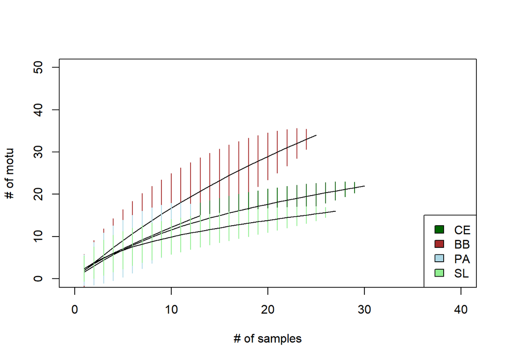

```r
specaccum(PA.matrix.motu.phaeton_S) -> accum.phaeton_S
specaccum(PA.matrix.motu.phaeton_W) -> accum.phaeton_W

specaccum(PA.matrix.motu.sula_leuco_S) -> accum.sula_leuco_S
specaccum(PA.matrix.motu.sula_leuco_W) -> accum.sula_leuco_W

plot(accum.bulweria, xlim = c(0,40), ylim = c(0,50), xlab = "# of samples", ylab = "# of motu", ci.col="brown")
plot(accum.calonectris, ci.col="darkgreen", add=T)
plot(accum.phaeton_S, ci.col="lightblue", add=T)
plot(accum.sula_leuco_S, ci.col="lightgreen", add=T)
legend(x="bottomright", legend=c("CE", "BB", "PA", "SL"), fill=c("darkgreen", "brown", "lightblue", "lightgreen"))
```

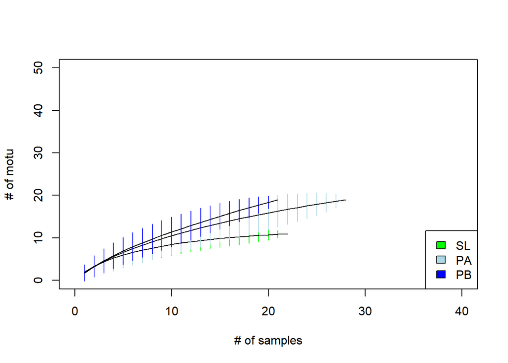

```r
plot(accum.sula_leuco_W, xlim = c(0,40), ylim = c(0,50), xlab = "# of samples", ylab = "# of motu", ci.col="green")
plot(accum.phaeton_W, ci.col="lightblue", add=T)
plot(accum.puffinus, ci.col="blue", add=T)
legend(x="bottomright", legend=c("SL", "PA", "PB"), fill=c("green", "lightblue", "blue") )
```

### 3.3.2 Extrapolation of MOTU Diversity

```r
incidence.matrix.motu.phaeton_S <- as.data.frame(t(PA.matrix.motu.phaeton_S))
incidence.matrix.motu.phaeton_W <- as.data.frame(t(PA.matrix.motu.phaeton_W))
incidence.matrix.motu.sula_leuco_S <- as.data.frame(t(PA.matrix.motu.sula_leuco_S))
incidence.matrix.motu.sula_leuco_W <- as.data.frame(t(PA.matrix.motu.sula_leuco_W))

list_seabirds_summer = list(CE = incidence.matrix.motu.calonectris, BB = incidence.matrix.motu.bulweria, "PA(S)" = incidence.matrix.motu.phaeton_S, "SL(S)" = incidence.matrix.motu.sula_leuco_S)

list_seabirds_winter = list(PB = incidence.matrix.motu.puffinus, "PA(W)" = incidence.matrix.motu.phaeton_W, "SL(W)" = incidence.matrix.motu.sula_leuco_W)

ChaoEst_summer <- ChaoRichness(list_seabirds_summer, datatype="incidence_raw", conf = 0.95)
ChaoEst_summer
```

|  | Observed | Estimator | Est_s.e. | 95% Lower | 95% Upper |
| --- | --- | --- | --- | --- | --- |
| CE | 22 | 56.800 | 32.311 | 29.420 | 185.203 |
| BB | 34 | 73.497 | 22.855 | 47.776 | 147.243 |
| PA(S) | 15 | 81.462 | 77.175 | 25.866 | 421.497 |
| SL(S) | 16 | 46.815 | 38.146 | 20.659 | 219.831 |

```r
ChaoEst_winter <- ChaoRichness(list_seabirds_winter, datatype="incidence_raw", conf = 0.95)
ChaoEst_winter
```

|  | Observed | Estimator | Est_s.e. | 95% Lower | 95% Upper |
| --- | --- | --- | --- | --- | --- |
| PB | 19 | 45.825 | 22.093 | 25.547 | 128.912 |
| PA(W) | 19 | 35.071 | 14.335 | 22.588 | 90.990 |
| SL(W) | 11 | 15.295 | 6.881 | 11.471 | 50.158 |

Plots

```r
seabirds_diversity_summer <- iNEXT(list_seabirds_summer, datatype="incidence_raw")
seabirds_diversity_summer
```

```
## Compare 4 assemblages with Hill number order q = 0.
## $class: iNEXT
##
## $DataInfo: basic data information
##    site  T  U S.obs     SC Q1 Q2 Q3 Q4 Q5 Q6 Q7 Q8 Q9 Q10
## 1    CE 30 48    22 0.7528 12  2  3  3  1  1  0  0  0   0
## 2    BB 25 49    34 0.5218 24  7  1  2  0  0  0  0  0   0
## 3 PA(S) 13 27    15 0.5616 12  1  0  1  0  0  0  0  1   0
## 4 SL(S) 27 65    16 0.8781  8  1  2  1  0  1  0  2  0   0
##
## $iNextEst: diversity estimates with rarefied and extrapolated samples.
## $CE
##     t       method order     qD qD.LCL qD.UCL    SC SC.LCL SC.UCL
## 1   1 interpolated     0  1.600  1.111  2.089 0.078  0.025  0.130
## 10 15 interpolated     0 15.002 11.327 18.677 0.636  0.486  0.787
## 20 30     observed     0 22.000 16.041 27.959 0.753  0.616  0.889
## 30 44 extrapolated     0 27.145 19.039 35.252 0.789  0.646  0.932
## 40 60 extrapolated     0 32.101 21.294 42.908 0.825  0.680  0.969
##
## $BB
##     t       method order     qD qD.LCL qD.UCL    SC SC.LCL SC.UCL
## 1   1 interpolated     0  1.960  1.374  2.546 0.037  0.010  0.065
## 10 12 interpolated     0 19.463 14.688 24.237 0.335  0.214  0.456
## 20 25     observed     0 34.000 26.031 41.969 0.522  0.393  0.651
## 30 37 extrapolated     0 43.889 33.268 54.510 0.642  0.499  0.784
## 40 50 extrapolated     0 51.829 38.324 65.333 0.738  0.589  0.886
##
## $`PA(S)`
##     t       method order     qD qD.LCL qD.UCL    SC SC.LCL SC.UCL
## 1   1 interpolated     0  2.077  1.472  2.682 0.265  0.117  0.414
## 2   1 interpolated     0  2.077  1.472  2.682 0.265  0.117  0.414
## 10  6 interpolated     0  8.220  5.266 11.175 0.505  0.347  0.663
## 20 13     observed     0 15.000  9.076 20.924 0.562  0.396  0.728
## 29 19 extrapolated     0 20.279 11.962 28.595 0.596  0.420  0.773
## 30 19 extrapolated     0 20.279 11.962 28.595 0.596  0.420  0.773
## 40 26 extrapolated     0 25.910 14.881 36.939 0.634  0.449  0.819
##
## $`SL(S)`
##     t       method order     qD qD.LCL qD.UCL    SC SC.LCL SC.UCL
## 1   1 interpolated     0  2.407  1.993  2.822 0.399  0.308  0.489
## 10 13 interpolated     0 11.274  8.186 14.362 0.830  0.749  0.911
## 20 27     observed     0 16.000 10.456 21.544 0.878  0.798  0.958
## 30 40 extrapolated     0 19.605 11.857 27.353 0.892  0.811  0.974
## 40 54 extrapolated     0 23.016 12.887 33.145 0.906  0.824  0.988
##
##
## $AsyEst: asymptotic diversity estimates along with related statistics.
##     Site         Diversity Observed Estimator   s.e.    LCL     UCL
## 1     CE  Species richness   22.000    56.800 32.311 29.420 185.203
## 2     CE Shannon diversity   17.624    29.729  7.551 17.624  44.528
## 3     CE Simpson diversity   14.769    20.226  3.971 14.769  28.009
## 4     BB  Species richness   34.000    73.497 22.855 47.776 147.243
## 5     BB Shannon diversity   29.970    65.199 18.868 29.970 102.179
## 6     BB Simpson diversity   25.817    51.356 12.519 26.819  75.894
## 7  PA(S)  Species richness   15.000    81.462 77.175 25.866 421.497
## 8  PA(S) Shannon diversity   10.041    26.794 12.007 10.041  50.328
## 9  PA(S) Simpson diversity    6.451     7.612  3.001  6.451  13.494
## 10 SL(S)  Species richness   16.000    46.815 38.146 20.659 219.831
## 11 SL(S) Shannon diversity    8.843    11.693  2.252  8.843  16.107
## 12 SL(S) Simpson diversity    5.717     5.981  0.828  5.717   7.604
##
## NOTE: Only show five estimates, call iNEXT.object$iNextEst. to show complete output.
```

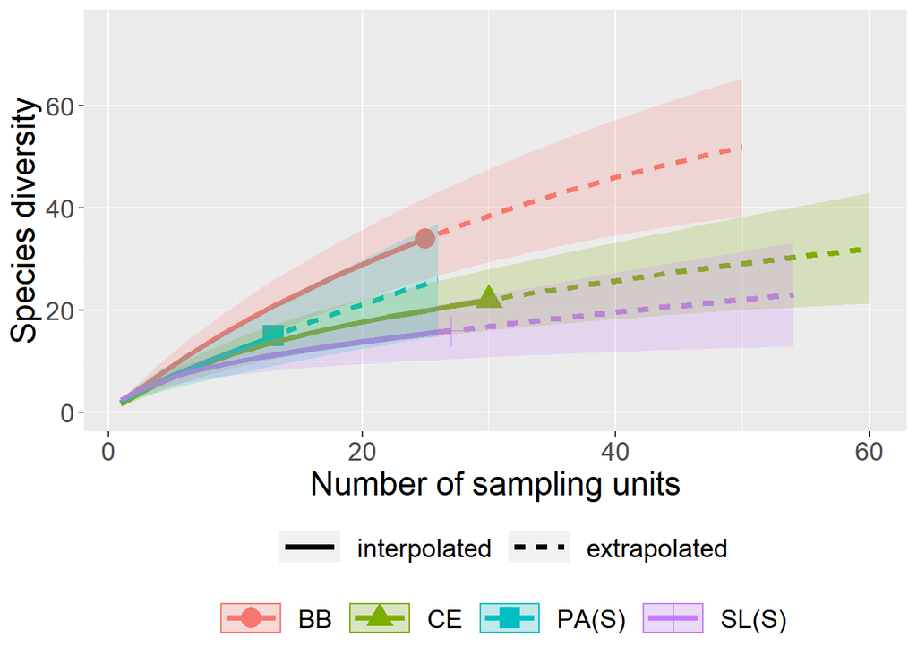

```r
ggiNEXT(seabirds_diversity_summer) + ylim (c(0,75))
```

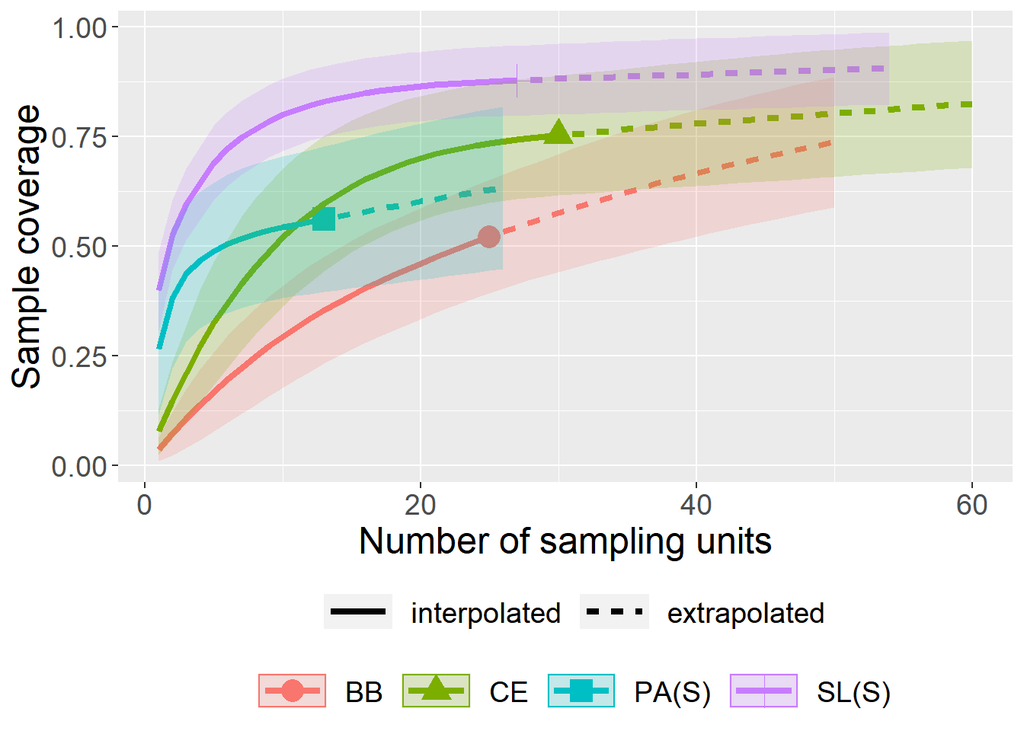

```r
ggiNEXT(seabirds_diversity_summer, type = 2)
```

```r
seabirds_diversity_winter <- iNEXT(list_seabirds_winter, datatype="incidence_raw")
seabirds_diversity_winter
```

```
## Compare 3 assemblages with Hill number order q = 0.
## $class: iNEXT
##
## $DataInfo: basic data information
##    site  T  U S.obs     SC Q1 Q2 Q3 Q4 Q5 Q6 Q7 Q8 Q9 Q10
## 1    PB 21 37    19 0.6566 13  3  0  0  1  1  1  0  0   0
## 2 PA(W) 28 49    19 0.8004 10  3  2  2  0  0  1  0  0   0
## 3 SL(W) 22 43    11 0.9324  3  1  4  1  0  0  0  0  0   0
##
## $iNextEst: diversity estimates with rarefied and extrapolated samples.
## $PB
##     t       method order     qD qD.LCL qD.UCL    SC SC.LCL SC.UCL
## 1   1 interpolated     0  1.762  1.295  2.229 0.132  0.049  0.216
## 10 10 interpolated     0 11.371  8.648 14.093 0.558  0.418  0.698
## 20 21     observed     0 19.000 13.868 24.132 0.657  0.512  0.801
## 30 31 extrapolated     0 24.472 17.246 31.698 0.727  0.571  0.883
## 40 42 extrapolated     0 29.211 19.577 38.846 0.787  0.628  0.947
##
## $`PA(W)`
##     t       method order     qD qD.LCL qD.UCL    SC SC.LCL SC.UCL
## 1   1 interpolated     0  1.750  1.262  2.238 0.163  0.080  0.246
## 10 14 interpolated     0 12.955  9.779 16.130 0.693  0.584  0.802
## 20 28     observed     0 19.000 13.976 24.024 0.800  0.678  0.923
## 30 41 extrapolated     0 22.994 16.075 29.914 0.850  0.717  0.983
## 40 56 extrapolated     0 26.386 16.954 35.819 0.892  0.761  1.000
##
## $`SL(W)`
##     t       method order     qD qD.LCL qD.UCL    SC SC.LCL SC.UCL
## 1   1 interpolated     0  1.955  1.478  2.431 0.286  0.172  0.400
## 10 11 interpolated     0  8.788  6.780 10.797 0.840  0.768  0.912
## 20 22     observed     0 11.000  8.165 13.835 0.932  0.860  1.000
## 30 32 extrapolated     0 12.153  8.518 15.788 0.951  0.883  1.000
## 40 44 extrapolated     0 13.136  8.440 17.832 0.966  0.910  1.000
##
##
## $AsyEst: asymptotic diversity estimates along with related statistics.
##    Site         Diversity Observed Estimator   s.e.    LCL     UCL
## 1    PB  Species richness   19.000    45.825 22.093 25.547 128.912
## 2    PB Shannon diversity   13.768    25.024  7.402 13.768  39.531
## 3    PB Simpson diversity   10.141    12.992  3.623 10.141  20.092
## 4 PA(W)  Species richness   19.000    35.071 14.335 22.588  90.990
## 5 PA(W) Shannon diversity   12.930    18.586  3.475 12.930  25.397
## 6 PA(W) Simpson diversity    9.060    10.536  2.324  9.060  15.090
## 7 SL(W)  Species richness   11.000    15.295  6.881 11.471  50.158
## 8 SL(W) Shannon diversity    7.898     9.340  1.406  7.898  12.095
## 9 SL(W) Simpson diversity    6.143     6.727  1.217  6.143   9.112
##
## NOTE: Only show five estimates, call iNEXT.object$iNextEst. to show complete output.
```

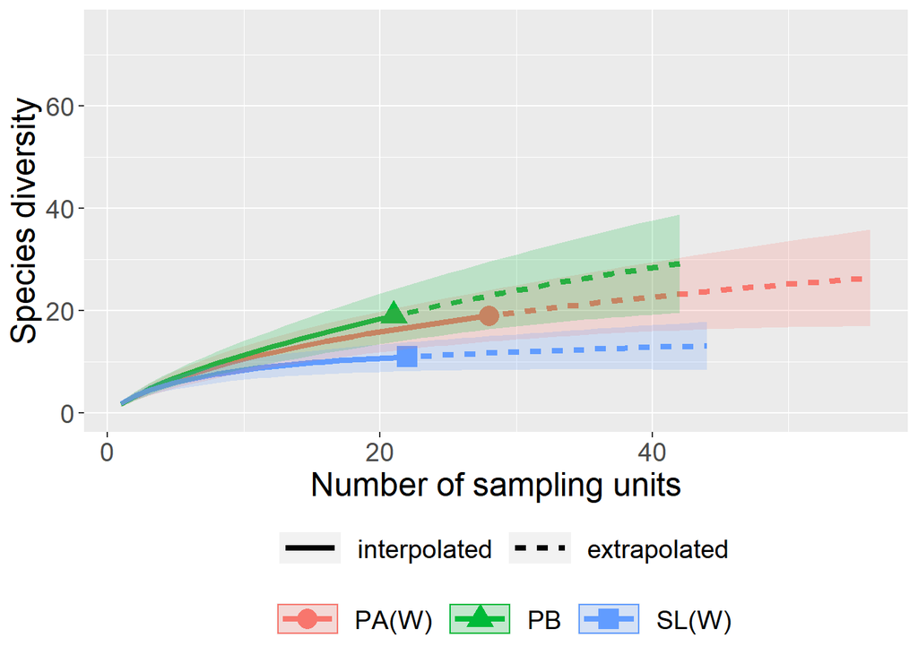

```r
ggiNEXT(seabirds_diversity_winter) + ylim (c(0,75))
```

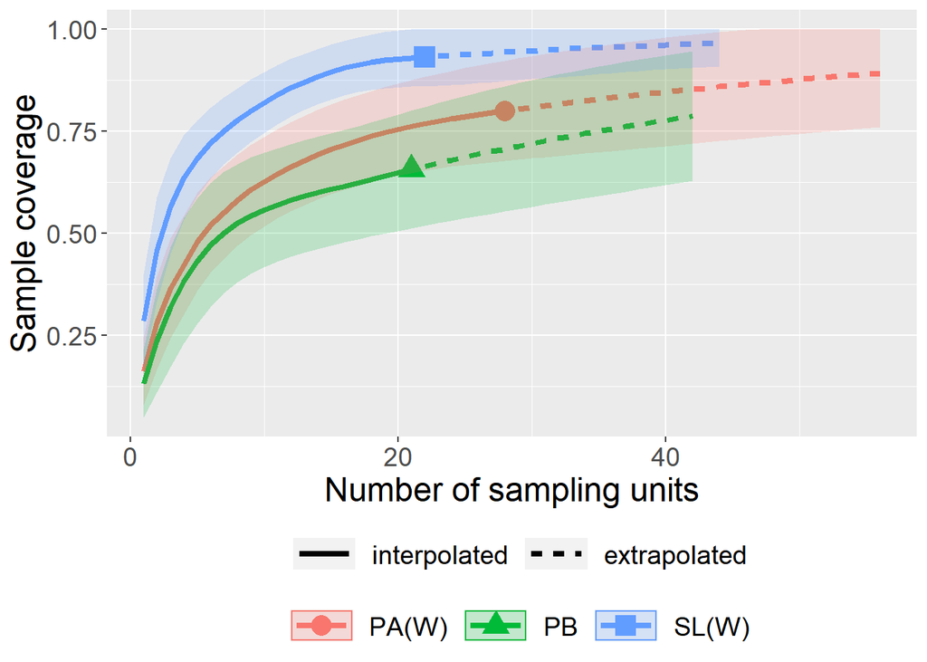

```r
ggiNEXT(seabirds_diversity_winter, type = 2)
```

## 3.4 Network analysis using FO%

```r
host_season.net.matrix <- host_season.matrix.motu.long.good[,c(1,3,6)] %>% filter(prop > 0) %>% dplyr::rename(higher = host_season, lower = Species, freq = prop)
host_season.net.matrix$webID = "caboverde"
host_season.net.matrix <- host_season.net.matrix[, c(1, 2, 4, 3)]

seq.high <- as.data.frame(host_season.net.matrix$higher)%>% dplyr::rename(seq.high = "host_season.net.matrix$higher") %>% distinct(seq.high)
seq.low <- as.data.frame(host_season.net.matrix$lower)%>% dplyr::rename(seq.low = "host_season.net.matrix$lower") %>% distinct(seq.low)

host_season.network <- frame2webs(data.frame(host_season.net.matrix),type.out="list")
```

### 3.4.1 Species level metrics

```r
specieslevel(host_season.network$caboverde, index=c("normalised degree", "d"))
```

```
## $`higher level`
##           normalised.degree         d
## BB_Summer         0.4533333 0.6103798
## CE_Summer         0.2933333 0.4431942
## PA_Summer         0.2000000 0.4446640
## PA_Winter         0.2533333 0.2776279
## PB_Winter         0.2533333 0.4552835
## SL_Summer         0.2133333 0.2767248
## SL_Winter         0.1466667 0.2894460
##
## $`lower level`
##                               normalised.degree          d
## Acanthuridae                          0.1428571 0.30142163
## Acanthurus sp.                        0.1428571 0.27164552
## Apletodon sp.                         0.1428571 0.27164552
## Argyropelecus sladeni                 0.1428571 0.27164552
## Arothron sp.                          0.5714286 0.17138383
## Assimineidae                          0.1428571 0.27164552
## Asthenognathus atlanticus             0.1428571 0.30142163
## Atherina sp.                          0.1428571 0.40567999
## Brotula sp.                           0.1428571 0.27164552
## Carangidae                            0.1428571 0.30142163
## Cavolinia uncinata                    0.1428571 0.36135275
## Cephalopholis sp.                     0.5714286 0.16769516
## Ceratoscopelus sp.                    0.1428571 0.27164552
## Chelon auratus                        0.1428571 0.37406984
## Chromis chromis                       1.0000000 0.03732622
## Conger conger                         0.1428571 0.26411470
## Coryphaena equiselis                  0.2857143 0.31134575
## Cyclothone pallida                    0.1428571 0.26411470
## Decapterus macarellus                 0.5714286 0.14832554
## Decapterus punctactus                 0.1428571 0.27883800
## Derichthys serpentinus                0.1428571 0.26411470
## Diacria sp.1                          0.1428571 0.36135275
## Diacria sp.2                          0.1428571 0.36135275
## Diplodus sargus                       0.1428571 0.27164552
## Diplodus vulgaris                     0.1428571 0.27164552
## Engraulis encrasicolus                0.4285714 0.27440599
## Engraulis sp.                         0.1428571 0.27164552
## Exocoetidae                           0.1428571 0.30142163
```

[output cut: 32 more lines]

```
## Scomberesox sp.                       0.1428571 0.25036364
## Selene setapinnis                     0.2857143 0.27073861
## Seriola lalandi                       0.4285714 0.23143135
## Solea senegalensis                    0.1428571 0.27164552
## Sparidae 1                            0.1428571 0.37406984
## Sparidae 2                            0.1428571 0.27164552
## Squalus sp.                           0.1428571 0.37406984
## Sternoptyx pseudopallida              0.1428571 0.27164552
## Sthenoteuthis pteropus                0.1428571 0.25036364
## Stomiidae                             0.1428571 0.26411470
## Symphodus bailloni                    0.1428571 0.27164552
## Symphodus melops                      0.1428571 0.27164552
## Thunnus sp.1                          0.2857143 0.33930557
## Thunnus sp.2                          0.8571429 0.12938484
## Trichiuridae                          0.1428571 0.36135275
```

### 3.4.2 Network level metrics

- **Network indices**

```r
network_indeces <- networklevel(host_season.network$caboverde, index=c("weighted NODF", "H2"))
network_indeces
```

```
## weighted NODF            H2
##    14.3243937     0.4371624
```

- **Modularity**

```r
host_season.net.mod <- metaComputeModules(host_season.network$caboverde, N=500)
obs_Q <- host_season.net.mod@likelihood
obs_Q
```

```
## [1] 0.379015
```

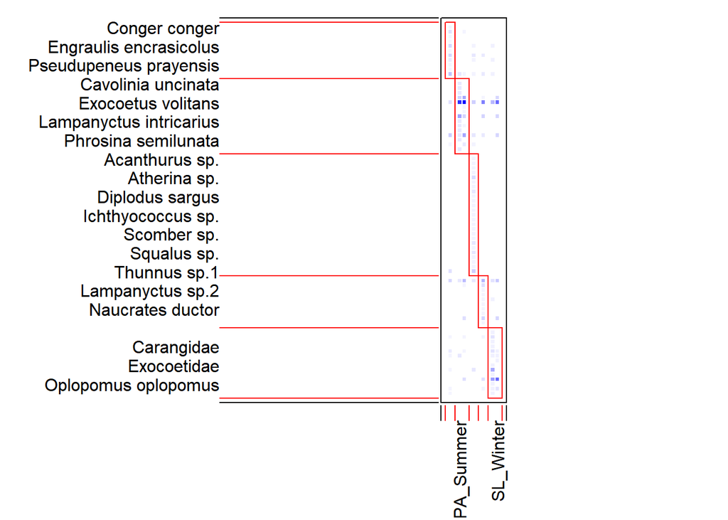

```r
plotModuleWeb(host_season.net.mod)
```